# FADN2Footprint — Validation Report

Comparison of package estimates with literature values

Author

Sarah HUET & Valentin BELLASSEN

Published

November 6, 2026

# Setup

```r
library(dplyr)
library(tidyr)
library(stringr)
library(gt)

library(ggplot2)

wd_path <- "C:/Users/srhuet/OneDrive/Research/GitHub/FADN2Footprint"

devtools::load_all(wd_path)
#library(FADN2Footprint)
```

# Purpose

This report compares the outputs of `FADN2Footprint` (v1.1.1) against published literature ranges. An estimate is flagged **in range** if it falls within the literature min–max, **within tolerance** if the relative deviation from the literature midpoint is below a per-indicator threshold, or **out of range** otherwise.

# Produce package estimates

[output not shown]

```
Create the FADN2Footprint S4 object
```

```
FADN2Footprint has only been validated for cereals (TF14=15) and dairy farms (TF14=45).

    Results for other types may be unreliable. Consider filtering your data first.
229 columns contain only zeros and will be removed.
229 are removed. Their names are stored in `object@traceability$columns$columns_removed`
Detected FADN column version: var_common

~~~ Parsing farm characteristics ~~~

Farm-level variables kept in object:
```

```
# A tibble: 15 × 4
   var_common DESCRIPTION                           Comment                Group
   <chr>      <chr>                                 <chr>                  <chr>
 1 COUNTRY    Country (3 digits FADN acronym)       codes used by DG AGRI… FARM…
 2 TF_SUBP4   Subparticular TF (4 digits)           4-digit Calculated by… FARM…
 3 TF14       Type of Farming (14)                  farming type classifi… FARM…
 4 TF8        Type of Farming (8)                   farming type classifi… FARM…
 5 YEAR       Year                                  accounting year        FARM…
 6 NUTS0      NUTS NUTS0                            only on demand - esti… GENE…
 7 NUTS1      NUTS NUTS1                            only on demand - esti… GENE…
 8 NUTS2      NUTS NUTS2                            only on demand - esti… GENE…
 9 ORGANIC    Organic farming Code                  From 2000              GENE…
10 SIZC       Economic size class (cf. EU typology) Calculated by DG AGRI  GENE…
11 ID         Unique Identifier                     Anonymous code allowi… REFE…
12 SYS02      Farms represented                     number of farm repres… REFE…
13 SE025      Total Utilised Agricultural Area      Area in ha             STAN…
14 SE080      Total livestock units                 in Livestock unit (co… STAN…
15 SE131      Total output                          in EUR                 STAN…
```

```
~~~ Parsing crop data ~~~

Make sure that your area variables are in hectare and your production variables are in tonnes.

Only variables for these crop codes are considered: CYNG, CWINEPGI, CWINEPDO, CWINEOTH, CWHTD, CWHTC, CWDED, CVEGUG, CVEGOTH, CVEGOF, CVEGMG, CUNUSEDLND, CTOMAT, CTOBAC, CSUGCN, CSUGBTTOP, CSUGBT, CSTRBER, CSTNFRUT, CSOYA, CSNFL, CRYE, CRICE, CRG, CRENTOUTLND, CRAPE, CRAISIN, CPOTST, CPOTOTH, CPOTD,…

We keep only arable and grass land use types (see`data_extra$crops`). We remove other land uses, fallows and rented land (9.58% of initial crop x farm x year observations) and store them in `object@traceability$other_land_use`

We remove 10617654 observations (85.83% of initial crop x farm x year observations) that had no area nor production. We store them in `object@traceability$removed_crops`.

~~~ Parsing herd data ~~~

Make sure that your livestock variables are in the same units as those described in the dictionary (i.e., either livestock unit or number of animals).

Only variables for these livestock codes are considered: LSOWBRE, LSHEPOTH, LRABOTH, LRABBRE, LPLTROTH, LPLTRBROYL, LPIGOTH, LPIGLET, LPIGFAT, LHENSLAY, LHEIFFAT, LHEIFBRE, LGOATOTH, LGOATBRE, LEWEBRE, LEQD, LCOWOTH, LCOWDAIR, LBOV2, LBOV1_2M, LBOV1_2F, LBOV1

~~~ Parsing input data ~~~

Make sure that your input variables are in the same units as those described in the dictionary (i.e., euros or tonnes).

Only these input variables are considered: IGRFEDCNCTRPUR_V, IGRFEDCRSPUR_V, INUSE_Q, IPROT_V, IFULS_V (see dictionnary)

~~~ Parsing output data ~~~

Production variables must use dictionary units (EUR or tonnes).
Animal products considered: PWOOL, PMLKSHEP, PMLKGOAT, PMLKCOW, PMLKBUF, PHONEY, PEGGH, PEGGC
Crop production and slaughtered animals are included.

~~~ Building FADN2Footprint object ~~~

Data for 132025 farms have been gathered into a FADN2Footprint object.
```

```
Infer the practices
```

```
We consider that crop productions are recorded as dry matter.
64832 observations have no livestock. They receive the average organic N input for farms that do not produce manure (see Methods).
8403 observations have not enough N excretion from their livestock. They receive the minimum organic N threshold as a standard value (see Methods).
50287 observations have too much N excretion from their livestock. They receive the maximum organic N threshold as a standard value (see Methods).
55326 observations have enough and not too much N excretion from their livestock. They spread the total N excreted from their livestock on-farm (see Methods).

Nitrogen fertilization variables are in ton of N ha-1.
Using cached values stored in object@practices$crops$N_ferti.
We consider that crop productions are recorded as dry matter.
We consider that crop productions are recorded as dry matter.
1158 farm x year observations with animals under contract are removed.
Using cached values stored in object@practices$herding$feed.
Using cached values stored in object@practices$herding$activities.
Using cached values stored in object@practices$herding$activities.
Using cached values stored in object@practices$herding$activities.
Using cached values stored in object@practices$herding$activities.
Using cached values stored in object@practices$herding$pseudoherd$animals.
19458 out of 132025 (15%) observations with non valid practices are discarded from the S4 object slots (see object@traceability$discarded_farms$problem).

Removed farms are stored in `object@traceability$discarded_farms`.
```

```
Compute the GHGE
```

[output not shown]

```
FADN dataset loaded: 32679 farm-year observations
```

```
Countries covered: FRA
```

```
Years covered: 2017, 2018, 2019, 2020, 2021
```

```r
object = my_object_GHGE

# Crops
summary(object@crop)
```

```
      ID                YEAR             COUNTRY          FADN_code_letter
 Length:140750      Length:140750      Length:140750      Length:140750
 Class :character   Class :character   Class :character   Class :character
 Mode  :character   Mode  :character   Mode  :character   Mode  :character




       A               ENA                IRA               PRQ
 Min.   :  0.00   Min.   : 0.00000   Min.   :  0.000   Min.   :    0.00
 1st Qu.:  4.35   1st Qu.: 0.00000   1st Qu.:  0.000   1st Qu.:    0.00
 Median : 11.41   Median : 0.00000   Median :  0.000   Median :   21.11
 Mean   : 22.04   Mean   : 0.02365   Mean   :  1.493   Mean   :  168.32
 3rd Qu.: 27.05   3rd Qu.: 0.00000   3rd Qu.:  0.000   3rd Qu.:  120.70
 Max.   :950.00   Max.   :92.50000   Max.   :607.280   Max.   :19680.90
                  NA's   :541        NA's   :319       NA's   :2476
       SQ                SV                TA               TO
 Min.   :    0.0   Min.   :      0   Min.   :  0.00   Min.   :-194600
 1st Qu.:    0.0   1st Qu.:      0   1st Qu.:  0.00   1st Qu.:      0
 Median :    8.5   Median :   4276   Median :  3.58   Median :   6758
 Mean   :  154.8   Mean   :  41153   Mean   : 11.41   Mean   :  43054
 3rd Qu.:  105.2   3rd Qu.:  27971   3rd Qu.: 14.52   3rd Qu.:  30509
 Max.   :19680.9   Max.   :4862533   Max.   :317.13   Max.   :4924968
 NA's   :2524      NA's   :319                        NA's   :319
       CV              IRTA            SE025            TA_sum
 Min.   :   0.0   Min.   : 0.000   Min.   :  0.01   Min.   :  0.00
 1st Qu.:   0.0   1st Qu.: 0.200   1st Qu.: 54.02   1st Qu.: 14.03
 Median :   0.0   Median : 7.030   Median :102.79   Median : 41.73
 Mean   : 136.8   Mean   : 8.369   Mean   :120.23   Mean   : 68.15
 3rd Qu.:   0.0   3rd Qu.:14.935   3rd Qu.:163.65   3rd Qu.: 99.05
 Max.   :3555.0   Max.   :30.710   Max.   :950.00   Max.   :718.66
 NA's   :140724   NA's   :140528
    area_ha           prod_t             sales_t        land_use_type
 Min.   :  0.00   Min.   :     0.00   Min.   :    0.0   Length:140750
 1st Qu.:  4.37   1st Qu.:    25.72   1st Qu.:    0.0   Class :character
 Median : 11.43   Median :    83.51   Median :    8.5   Mode  :character
 Mean   : 22.04   Mean   :   810.01   Mean   :  154.8
 3rd Qu.: 27.06   3rd Qu.:   244.74   3rd Qu.:  105.2
 Max.   :950.00   Max.   :912477.78   Max.   :19680.9
                                      NA's   :2524
```

[output cut: 16 more lines]

```
 default_crop_prod default_sales_to_prod default_avrg_yield_crop
 Mode :logical     Mode :logical         Mode :logical
 FALSE:132489      FALSE:140706          FALSE:137078
 TRUE :8261        TRUE :44              TRUE :3672




  sum_area_ha       sum_prod_t       keep_sup5pc
 Min.   :  0.01   Min.   :     0.0   Mode:logical
 1st Qu.: 53.20   1st Qu.:   444.8   TRUE:140750
 Median :101.51   Median :   791.8
 Mean   :119.41   Mean   :  5533.2
 3rd Qu.:162.52   3rd Qu.:  1485.4
 Max.   :950.00   Max.   :913464.4
```

```r
(object@crop |>
    dplyr::filter(is.na(prod_t)))
```

```
# A tibble: 0 × 34
# ℹ 34 variables: ID <chr>, YEAR <chr>, COUNTRY <chr>, FADN_code_letter <chr>,
#   A <dbl>, ENA <dbl>, IRA <dbl>, PRQ <dbl>, SQ <dbl>, SV <dbl>, TA <dbl>,
#   TO <dbl>, CV <dbl>, IRTA <dbl>, SE025 <dbl>, TA_sum <dbl>, area_ha <dbl>,
#   prod_t <dbl>, sales_t <dbl>, land_use_type <chr>, species <chr>,
#   yield <dbl>, NUTS0 <chr>, NUTS1 <chr>, NUTS2 <chr>,
#   default_forage_yield <lgl>, default_forage_prod <lgl>,
#   default_crop_yield <lgl>, default_crop_prod <lgl>, …
```

```r
#sort(table(object@crop |> filter(is.na(prod_t)) |> pull(FADN_code_letter)), decreasing = TRUE)
#table(object@crop |> filter(is.na(prod_t)) |> pull(keep_sup5pc))
#
#
## GHGE crops
#
summary(object@footprints$GHGE$GHGE_crops)
```

```
      ID                YEAR             COUNTRY          FADN_code_letter
 Length:140750      Length:140750      Length:140750      Length:140750
 Class :character   Class :character   Class :character   Class :character
 Mode  :character   Mode  :character   Mode  :character   Mode  :character




    area_ha           prod_t           N2O_d_kgCO2e      N2O_ATD_kgCO2e
 Min.   :  0.00   Min.   :     0.00   Min.   :       0   Min.   :    0.0
 1st Qu.:  4.37   1st Qu.:    25.72   1st Qu.:    2425   1st Qu.:  198.5
 Median : 11.43   Median :    83.51   Median :    8559   Median :  823.0
 Mean   : 22.04   Mean   :   810.01   Mean   :   33975   Mean   : 1962.8
 3rd Qu.: 27.06   3rd Qu.:   244.74   3rd Qu.:   23416   3rd Qu.: 2503.5
 Max.   :950.00   Max.   :912477.78   Max.   :25037895   Max.   :68070.4

  N2O_L_kgCO2e      ghg_ferti_prod_kgCO2e ghg_heat_fuel_kgCO2e
 Min.   :       0   Min.   :     0.0      Min.   :      0
 1st Qu.:     963   1st Qu.:   279.3      1st Qu.:      0
 Median :    3301   Median :  2541.3      Median :      0
 Mean   :   14742   Mean   :  8363.6      Mean   :   1298
 3rd Qu.:    9153   3rd Qu.:  8780.2      3rd Qu.:      0
 Max.   :12004889   Max.   :573823.7      Max.   :4243320
                                          NA's   :27
 ghg_diesel_tillage_kgCO2e ghg_diesel_remain_kgCO2e ghg_elec_kgCO2e
 Min.   :     0.0          Min.   :    0            Min.   :    0.00
 1st Qu.:   500.9          1st Qu.:    0            1st Qu.:    0.00
 Median :  2937.9          Median :  223            Median :   14.27
 Mean   :  6676.0          Mean   : 1565            Mean   :  252.77
 3rd Qu.:  8203.0          3rd Qu.: 1745            3rd Qu.:  146.27
 Max.   :257475.8          Max.   :52304            Max.   :46936.62
 NA's   :27                NA's   :27               NA's   :27
 total_ghg_crop_kgCO2e N2O_d_kgCO2e_per_ha N2O_d_kgCO2e_per_t
 Min.   :       0      Min.   :     8.5    Min.   :     0.06
 1st Qu.:    7817      1st Qu.:   405.6    1st Qu.:    52.23
 Median :   23264      Median :   763.2    Median :    96.22
 Mean   :   68834      Mean   :  2436.6    Mean   :   132.68
 3rd Qu.:   57122      3rd Qu.:  1087.1    3rd Qu.:   143.06
 Max.   :37086153      Max.   :318679.7    Max.   :343406.71
                                           NA's   :1879
```

[output cut: 41 more lines]

```
 Min.   :     0.00      Min.   :    0.000     Min.   :1.483e+01
 1st Qu.:     0.00      1st Qu.:    0.000     1st Qu.:1.100e+03
 Median :     1.46      Median :    0.160     Median :2.123e+03
 Mean   :    48.88      Mean   :    3.975     Mean   :5.592e+03
 3rd Qu.:    11.50      3rd Qu.:    1.431     3rd Qu.:3.143e+03
 Max.   :332273.43      Max.   :48042.746     Max.   :1.065e+06
 NA's   :27             NA's   :1879
 total_ghg_crop_kgCO2e_per_t
 Min.   :6.070e+00
 1st Qu.:1.449e+02
 Median :2.544e+02
 Mean   :4.574e+02
 3rd Qu.:4.259e+02
 Max.   :2.394e+06
 NA's   :1879
```

```r
#
object@footprints$GHGE$GHGE_crops |>
  dplyr::filter(!is.finite(N2O_d_kgCO2e_per_t)) #|> View()
```

```
# A tibble: 1,879 × 33
   ID            YEAR  COUNTRY FADN_code_letter area_ha prod_t N2O_d_kgCO2e
   <chr>         <chr> <chr>   <chr>              <dbl>  <dbl>        <dbl>
 1 515000000728  2017  FRA     CNURS               3.23      0       1157.
 2 515000000340  2017  FRA     CFLWUG              1         0         56.3
 3 515000000340  2017  FRA     CFLW                1         0         56.3
 4 515000000247  2017  FRA     CFLWCUT             6         0        338.
 5 515000000247  2017  FRA     CFLWUG              6         0        338.
 6 515000000853  2017  FRA     CFLWUG              2.02      0        114.
 7 515000000853  2017  FRA     CFLW                2.02      0        114.
 8 515000000909  2017  FRA     CNURS               6.85      0        839.
 9 5650000006622 2017  FRA     CNURS               0.5       0         50.9
10 5650000006886 2017  FRA     CNURS               0.5       0        137.
# ℹ 1,869 more rows
# ℹ 26 more variables: N2O_ATD_kgCO2e <dbl>, N2O_L_kgCO2e <dbl>,
#   ghg_ferti_prod_kgCO2e <dbl>, ghg_heat_fuel_kgCO2e <dbl>,
#   ghg_diesel_tillage_kgCO2e <dbl>, ghg_diesel_remain_kgCO2e <dbl>,
#   ghg_elec_kgCO2e <dbl>, total_ghg_crop_kgCO2e <dbl>,
#   N2O_d_kgCO2e_per_ha <dbl>, N2O_d_kgCO2e_per_t <dbl>,
#   N2O_ATD_kgCO2e_per_ha <dbl>, N2O_ATD_kgCO2e_per_t <dbl>, …
```

```r
#sort(table(object@footprints$GHGE$GHGE_crops |> filter(is.na(prod_t)) |> pull(FADN_code_letter)), decreasing = TRUE)
```

# Literature references

```r
# TOTAL GHGE ----

lit_GHGE_total <- readxl::read_excel(
  file.path(wd_path, "inst/validation/validation_references.xlsx"),
  sheet = "summary_total_GHGE",
  col_types = c("text", "numeric", "numeric", "text", "text")
) |>
  # filter for references with both per ha and per t
  dplyr::filter(GHGE_kgCO2e_kg >0
                | GHGE_kgCO2e_ha >0) |>
  # filter for crops, meat, milk, and eggs
  dplyr::filter(grepl("wheat|maize_grain|rapeseed|milk|meat|eggs", product)) |>
  # filter values for France if present or EU otherwise for each product
  dplyr::group_by(product) |>
  dplyr::filter(
    if (any(grepl("France", area))) grepl("France", area) else TRUE
  ) |>
  dplyr::ungroup() |>
  # add set
  dplyr::mutate(set = "GHG Emissions")

# COMPONENTS OF GHGE ----

lit_GHGE_components <- readxl::read_excel(
  file.path(wd_path, "inst/validation/validation_references.xlsx"),
  sheet = "summary_share_components"
) |>
  # filter for crops, meat and milk
  dplyr::filter(grepl("wheat|maize_grain|rapeseed|milk|meat|eggs", product)) |>
  # filter values for France if present or EU otherwise for each product and component
  dplyr::group_by(product, Harmonized_Category) |>
  dplyr::filter(
    if (any(grepl("France", area))) grepl("France", area) else TRUE
  ) |>
  dplyr::ungroup() |>
  # remove unclassified components
  dplyr::filter(!is.na(Harmonized_Category)) |>
  # sum up by product,Harmonized_Category,sheet,area
  dplyr::summarise(
    dplyr::across(
      c(GHGE_kgCO2e_ha,GHGE_kgCO2e_kg),
      ~ sum(.x)
    ),
    .by = c('product','Harmonized_Category','sheet','area')
  ) |>
  # add set
  dplyr::mutate(set = "GHG Emissions")

cat("Literature (total GHGE) loaded:", nrow(lit_GHGE_total), "rows\n")
```

```
Literature (total GHGE) loaded: 102 rows
```

```r
cat("Literature (components of GHGE) loaded:", nrow(lit_GHGE_components), "rows\n")
```

```
Literature (components of GHGE) loaded: 49 rows
```

```r
lit_agri_pract <- readxl::read_excel(
  file.path(wd_path, "inst/validation/validation_references.xlsx"),
  sheet = "summary_agri_practices"
)

# add EPK averages for wheat fertilization ----
tmp = data_extra$PKGC_N_ferti |>
  dplyr::filter(EPK_ferti_crop_name == "Ble_tendre" & ORGANIC == 0) |>
  dplyr::select(N_min,Nmin_sd_w,N_org,Norg_sd_w)

lit_agri_pract <- lit_agri_pract |>
  dplyr::bind_rows(
    tibble::tibble(
      indicator = c("mineral fertilization", "organic fertilizer"),
      unit = "kg N / ha",
      product = "wheat",
      area = "France",
      lit_midpoint = c(tmp$N_min, tmp$N_org),
      lit_min = 0,
      lit_max = c((tmp$N_min + tmp$Nmin_sd_w), (tmp$N_org + tmp$Norg_sd_w)),
      #tolerance_pct = "More than half\n&\nLess than twice",
      lit_source = "EPK 2017"
    )
  ) |>
  # add set
  dplyr::mutate(set = "Agricultural practices")


cat("Literature (agricultural practices) loaded:", nrow(lit_agri_pract), "rows\n")
```

```
Literature (agricultural practices) loaded: 16 rows
```

```r
lit_GHGE_total |> arrange(set,product,sheet) |> gt()
```

| product | GHGE_kgCO2e_kg | GHGE_kgCO2e_ha | area | sheet | set |
| --- | --- | --- | --- | --- | --- |
| cattle_meat | 12.0000000 | 9931.000 | France | CAP2ER_2025_BV_E_JB_viande | GHG Emissions |
| cattle_meat | 18.1000000 | 4496.000 | France | CAP2ER_2025_BV_NE_boeufs | GHG Emissions |
| cattle_meat | 14.5000000 | 6460.620 | France | Extract_Agribalyse | GHG Emissions |
| eggs | 2.8800000 | NA | France | Clune_2017 | GHG Emissions |
| eggs | 3.1900000 | NA | France | Clune_2017 | GHG Emissions |
| eggs | 1.1800000 | 5063.667 | France | Extract_Agribalyse | GHG Emissions |
| maize_grain | 0.3560000 | 3684.997 | France | Extract_Agribalyse | GHG Emissions |
| meat_chicken | 2.7090909 | NA | France | Clune_2017 | GHG Emissions |
| meat_chicken | 2.9731169 | NA | France | Clune_2017 | GHG Emissions |
| meat_chicken | 3.5964935 | NA | France | Clune_2017 | GHG Emissions |
| meat_chicken | 4.2698701 | NA | France | Clune_2017 | GHG Emissions |
| meat_chicken | 4.6166667 | NA | France | Clune_2017 | GHG Emissions |
| meat_chicken | 5.3511111 | NA | France | Clune_2017 | GHG Emissions |
| meat_chicken | 5.3607792 | NA | France | Clune_2017 | GHG Emissions |
| meat_chicken | 5.3696296 | NA | France | Clune_2017 | GHG Emissions |
| meat_chicken | 5.9251852 | NA | France | Clune_2017 | GHG Emissions |
| meat_chicken | 6.1103704 | NA | France | Clune_2017 | GHG Emissions |
| meat_chicken | 1.9300000 | 6426.770 | France | Extract_Agribalyse | GHG Emissions |
| meat_pork | 2.9740000 | 4310.000 | France | Bellassen_2021 | GHG Emissions |
| meat_pork | 2.3000000 | 4240.000 | France | Chiriaco_2022 | GHG Emissions |
| meat_pork | 3.7865116 | NA | France | Clune_2017 | GHG Emissions |
| meat_pork | 3.8330233 | NA | France | Clune_2017 | GHG Emissions |
| meat_pork | 4.0190698 | NA | France | Clune_2017 | GHG Emissions |
| meat_pork | 4.2000000 | NA | France | Clune_2017 | GHG Emissions |
| meat_pork | 4.2516279 | NA | France | Clune_2017 | GHG Emissions |
| meat_pork | 4.3213953 | NA | France | Clune_2017 | GHG Emissions |
| meat_pork | 4.6702326 | NA | France | Clune_2017 | GHG Emissions |
| meat_pork | 5.0655814 | NA | France | Clune_2017 | GHG Emissions |
| meat_pork | 5.1000000 | NA | France | Clune_2017 | GHG Emissions |
| meat_pork | 5.1120930 | NA | France | Clune_2017 | GHG Emissions |

[output cut: 72 more lines]

```r
lit_GHGE_components |> arrange(set,product,Harmonized_Category,sheet) |> gt()
```

| product | Harmonized_Category | sheet | area | GHGE_kgCO2e_ha | GHGE_kgCO2e_kg | set |
| --- | --- | --- | --- | --- | --- | --- |
| cattle_meat | Energy Use (Diesel/Elec) | CAP2ER_2025_BV_E_JB_viande | France | 413.79167 | 0.50000000 | GHG Emissions |
| cattle_meat | Energy Use (Diesel/Elec) | CAP2ER_2025_BV_NE_boeufs | France | 298.07735 | 1.20000000 | GHG Emissions |
| cattle_meat | Enteric Fermentation | CAP2ER_2025_BV_E_JB_viande | France | 6041.35833 | 7.30000000 | GHG Emissions |
| cattle_meat | Enteric Fermentation | CAP2ER_2025_BV_NE_boeufs | France | 3104.97238 | 12.50000000 | GHG Emissions |
| cattle_meat | Fertilizer Production | CAP2ER_2025_BV_E_JB_viande | France | 165.51667 | 0.20000000 | GHG Emissions |
| cattle_meat | Fertilizer Production | CAP2ER_2025_BV_NE_boeufs | France | 24.83978 | 0.10000000 | GHG Emissions |
| cattle_meat | Field N2O Emissions | CAP2ER_2025_BV_E_JB_viande | France | 2234.47500 | 2.70000000 | GHG Emissions |
| cattle_meat | Field N2O Emissions | CAP2ER_2025_BV_NE_boeufs | France | 372.59669 | 1.50000000 | GHG Emissions |
| cattle_meat | Manure Management | CAP2ER_2025_BV_E_JB_viande | France | 993.10000 | 1.20000000 | GHG Emissions |
| cattle_meat | Manure Management | CAP2ER_2025_BV_NE_boeufs | France | 695.51381 | 2.80000000 | GHG Emissions |
| eggs | Energy Use (Diesel/Elec) | Lesschen_2011_compo | Europe | 333.33333 | NA | GHG Emissions |
| eggs | Enteric Fermentation | Lesschen_2011_compo | Europe | 0.00000 | NA | GHG Emissions |
| eggs | Fertilizer Production | Lesschen_2011_compo | Europe | 166.66667 | NA | GHG Emissions |
| eggs | Field N2O Emissions | Lesschen_2011_compo | Europe | 833.33333 | NA | GHG Emissions |
| eggs | Manure Management | Lesschen_2011_compo | Europe | 333.33333 | NA | GHG Emissions |
| eggs | Other Inputs & Processes | Lesschen_2011_compo | Europe | 166.66667 | NA | GHG Emissions |
| meat_chicken | Energy Use (Diesel/Elec) | Lesschen_2011_compo | Europe | 300.00000 | NA | GHG Emissions |
| meat_chicken | Enteric Fermentation | Lesschen_2011_compo | Europe | 0.00000 | NA | GHG Emissions |
| meat_chicken | Fertilizer Production | Lesschen_2011_compo | Europe | 300.00000 | NA | GHG Emissions |
| meat_chicken | Field N2O Emissions | Lesschen_2011_compo | Europe | 700.00000 | NA | GHG Emissions |
| meat_chicken | Manure Management | Lesschen_2011_compo | Europe | 300.00000 | NA | GHG Emissions |
| meat_chicken | Other Inputs & Processes | Lesschen_2011_compo | Europe | 200.00000 | NA | GHG Emissions |
| meat_pork | Energy Use (Diesel/Elec) | Bellassen_2021 | France | 206.00000 | 0.14200000 | GHG Emissions |
| meat_pork | Enteric Fermentation | Bellassen_2021 | France | 181.00000 | 0.12500000 | GHG Emissions |
| meat_pork | Fertilizer Production | Bellassen_2021 | France | 499.00000 | 0.34400000 | GHG Emissions |
| meat_pork | Field N2O Emissions | Bellassen_2021 | France | 207.00000 | 0.14300000 | GHG Emissions |
| meat_pork | Manure Management | Bellassen_2021 | France | 1233.00000 | 0.85100000 | GHG Emissions |
| meat_pork | Other Inputs & Processes | Bellassen_2021 | France | 177.00000 | 0.12200000 | GHG Emissions |
| milk | Energy Use (Diesel/Elec) | Bellassen_2021 | France | 250.00000 | 0.04500000 | GHG Emissions |
| milk | Energy Use (Diesel/Elec) | CAP2ER_2025_bovin_laitier | France | 549.91176 | 0.07000000 | GHG Emissions |
| milk | Enteric Fermentation | Bellassen_2021 | France | 3423.00000 | 0.61500000 | GHG Emissions |
| milk | Enteric Fermentation | CAP2ER_2025_bovin_laitier | France | 4477.85294 | 0.57000000 | GHG Emissions |
| milk | Fertilizer Production | Bellassen_2021 | France | 228.00000 | 0.04100000 | GHG Emissions |
| milk | Fertilizer Production | CAP2ER_2025_bovin_laitier | France | 157.11765 | 0.02000000 | GHG Emissions |
| milk | Field N2O Emissions | Bellassen_2021 | France | NA | NA | GHG Emissions |
| milk | Field N2O Emissions | CAP2ER_2025_bovin_laitier | France | 1649.73529 | 0.21000000 | GHG Emissions |
| milk | Land Use Change / Soil Carbon | Agribalyse_2025 | France | NA | 0.11525083 | GHG Emissions |
| milk | Manure Management | Bellassen_2021 | France | NA | NA | GHG Emissions |
| milk | Manure Management | CAP2ER_2025_bovin_laitier | France | 1099.82353 | 0.14000000 | GHG Emissions |
| milk | Other Inputs & Processes | Bellassen_2021 | France | 122.00000 | 0.02200000 | GHG Emissions |
| wheat | Energy Use (Diesel/Elec) | Bellassen_2021 | France | 228.00000 | 0.06200000 | GHG Emissions |
| wheat | Fertilizer Production | Bamber_2025_fig1 | France | 2623.30000 | 0.37000000 | GHG Emissions |
| wheat | Fertilizer Production | Bellassen_2021 | France | 871.00000 | 0.11500000 | GHG Emissions |
| wheat | Field N2O Emissions | Bamber_2025_fig1 | France | 1559.80000 | 0.22000000 | GHG Emissions |
| wheat | Field N2O Emissions | Bamber_2025_sup_tab5 | France | 3587.54000 | 0.50600000 | GHG Emissions |
| wheat | Field N2O Emissions | Bellassen_2021 | France | NA | NA | GHG Emissions |
| wheat | Land Use Change / Soil Carbon | Agribalyse_2025 | France | NA | 0.07210423 | GHG Emissions |
| wheat | Land Use Change / Soil Carbon | Bamber_2025_sup_tab5 | France | 609.74000 | 0.08600000 | GHG Emissions |
| wheat | Other Inputs & Processes | Bellassen_2021 | France | 216.00000 | 0.02800000 | GHG Emissions |

```r
lit_agri_pract |> arrange(set,indicator) |> gt()
```

| indicator | unit | product | area | lit_midpoint | lit_min | lit_max | lit_source | set |
| --- | --- | --- | --- | --- | --- | --- | --- | --- |
| DMI | kg / head / day | dairy_cows | Germany | NA | 8 | 24.0000 | Flachowsky_2002 | Agricultural practices |
| GE | MJ / head / day | dairy_cows | France | 3.080000e+02 | NA | NA | Bellassen_2021 | Agricultural practices |
| Nex | kg N / head / year | dairy_cows | France | 1.159100e+02 | NA | NA | UNFCCC_2020 | Agricultural practices |
| feed_Energy rich feed | percent | dairy_cows | Europe | 5.524862e-03 | NA | NA | Lesschen_2011 | Agricultural practices |
| feed_Feed cereals | percent | dairy_cows | Europe | 2.569061e-01 | NA | NA | Lesschen_2011 | Agricultural practices |
| feed_Fodder maize | percent | dairy_cows | Europe | 7.458564e-02 | NA | NA | Lesschen_2011 | Agricultural practices |
| feed_Fodder root crops | percent | dairy_cows | Europe | 2.762431e-03 | NA | NA | Lesschen_2011 | Agricultural practices |
| feed_Grass | percent | dairy_cows | Europe | 2.900552e-01 | NA | NA | Lesschen_2011 | Agricultural practices |
| feed_Other feed | percent | dairy_cows | Europe | 1.104972e-02 | NA | NA | Lesschen_2011 | Agricultural practices |
| feed_Other fodder | percent | dairy_cows | Europe | 1.602210e-01 | NA | NA | Lesschen_2011 | Agricultural practices |
| feed_Protein rich feed | percent | dairy_cows | Europe | 1.988950e-01 | NA | NA | Lesschen_2011 | Agricultural practices |
| first_calving_age | month | dairy_cows | France | 3.000000e+01 | 27 | 32.0000 | CAP2ER_2025 | Agricultural practices |
| mineral fertilization | kg N / ha | wheat | France | 1.657839e+02 | 0 | 209.9956 | EPK 2017 | Agricultural practices |
| organic fertilizer | kg N / ha | wheat | France | 1.058427e+01 | 0 | 48.5810 | EPK 2017 | Agricultural practices |
| renewal_rate | percent | dairy_cows | France | 3.600000e+01 | 32 | 36.0000 | CAP2ER_2025 | Agricultural practices |
| share_concent | percent | dairy_cows | Germany | NA | 0 | 40.0000 | Flachowsky_2002 | Agricultural practices |

```r
lit_table = dplyr::bind_rows(
  lit_agri_pract,
  lit_GHGE_total |>
    dplyr::mutate(GHGE_kgCO2e_t = GHGE_kgCO2e_kg*10^3) |>
    tidyr::pivot_longer(cols = c(GHGE_kgCO2e_ha,GHGE_kgCO2e_t),
                        names_to = "indicator") |>
    dplyr::filter(!is.na(value)) |>
    dplyr::summarise(lit_midpoint = mean(value),
                     lit_min = min(value),
                     lit_max = max(value),
                     lit_source = paste0(unique(sheet),collapse = "; "),
                     area = paste0(unique(area),collapse = "; "),
                     .by = c('set', 'indicator', 'product')) |>
    dplyr::mutate(
      unit = ifelse(grepl("_ha",indicator),"kgCO2e_per_ha","kgCO2e_per_t")
    )
) |>
  dplyr::bind_rows(
    lit_GHGE_components |>
      dplyr::mutate(GHGE_kgCO2e_t = GHGE_kgCO2e_kg*10^3) |>
      tidyr::pivot_longer(cols = c(GHGE_kgCO2e_ha,GHGE_kgCO2e_t),
                          names_to = "indicator") |>
      dplyr::filter(!is.na(value)) |>
      dplyr::mutate(indicator = paste(indicator,Harmonized_Category,sep = "__")) |>
      dplyr::summarise(lit_midpoint = mean(value, na.rm = T),
                       lit_min = min(value, na.rm = T),
                       lit_max = max(value, na.rm = T),
                       lit_source = paste0(unique(sheet),collapse = "; "),
                       area = paste0(unique(area),collapse = "; "),
                       .by = c('set', 'indicator', 'product')) |>
      dplyr::mutate(
        unit = ifelse(grepl("_ha",indicator),"kgCO2e_per_ha","kgCO2e_per_t")
      )

  ) |>
  # arrange columns
  dplyr::select(set, indicator, unit, product, area, lit_midpoint, lit_min, lit_max, lit_source)
```

```r
# add global GHGE at farm scale from ADEME data base of carbon diagnosis
ADEME_desc_stat_TF <- read.csv((file.path(wd_path, "inst/validation/ADEME_desc_stat_TF.csv")))

lit_table <- dplyr::bind_rows(
  lit_table,
  ADEME_desc_stat_TF |>
    dplyr::filter(exploitation_otex %in% c(1500, 4500, 4600)) |>
    dplyr::mutate(
      set = "GHG Emissions",
      indicator = dplyr::case_when(
        variable == "emissions_ges_totales_exploitation" ~ "pseudofarm_total_ghge_kgCO2e",
        variable == "emissions_ges_co2" ~ "pseudofarm_total_CO2_kgCO2e",
        variable == "emissions_ges_ch4" ~ "pseudofarm_total_CH4_kgCO2e",
        variable == "emissions_ges_n2o" ~ "pseudofarm_total_N2O_kgCO2e",

        variable == "emissions_ges_totales_exploitation_per_ha" ~ "pseudofarm_total_ghge_kgCO2e_per_ha",
        variable == "emissions_ges_co2_per_ha" ~ "pseudofarm_total_CO2_kgCO2e_per_ha",
        variable == "emissions_ges_ch4_per_ha" ~ "pseudofarm_total_CH4_kgCO2e_per_ha",
        variable == "emissions_ges_n2o_per_ha" ~ "pseudofarm_total_N2O_kgCO2e_per_ha",

        variable == "emissions_ges_totales_exploitation_per_LU" ~ "pseudofarm_total_ghge_kgCO2e_per_LU",
        variable == "emissions_ges_co2_per_LU" ~ "pseudofarm_total_CO2_kgCO2e_per_LU",
        variable == "emissions_ges_ch4_per_LU" ~ "pseudofarm_total_CH4_kgCO2e_per_LU",
        variable == "emissions_ges_n2o_per_LU" ~ "pseudofarm_total_N2O_kgCO2e_per_LU"
      ),
      unit = dplyr::case_when(
        grepl("_per_ha$",variable) ~ "kgCO2e_per_ha",
        grepl("_per_LU$",variable) ~ "kgCO2e_per_LU",
        .default = "kgCO2e"
      ),
      product = dplyr::case_when(
        exploitation_otex == 1500 ~ "Field crop farms",
        exploitation_otex == 4500 ~ "Dairy farms",
        exploitation_otex == 4600 ~ "Beef farms"
      ),
      area = "France",
      lit_midpoint = mean,
      lit_min = pmax(mean - sd, 0, na.rm = T),
      lit_max = mean + sd,
      lit_source = "ADEME data base"
    ) |>
    dplyr::filter(!is.na(indicator)) |>
    # arrange columns
    dplyr::select(set, indicator, unit, product, area, lit_midpoint, lit_min, lit_max, lit_source)
)
```

```r
# Display

lit_table |> arrange(set, product, indicator) |> gt()
```

| set | indicator | unit | product | area | lit_midpoint | lit_min | lit_max | lit_source |
| --- | --- | --- | --- | --- | --- | --- | --- | --- |
| Agricultural practices | DMI | kg / head / day | dairy_cows | Germany | NA | 8.00000 | 24.0000 | Flachowsky_2002 |
| Agricultural practices | GE | MJ / head / day | dairy_cows | France | 3.080000e+02 | NA | NA | Bellassen_2021 |
| Agricultural practices | Nex | kg N / head / year | dairy_cows | France | 1.159100e+02 | NA | NA | UNFCCC_2020 |
| Agricultural practices | feed_Energy rich feed | percent | dairy_cows | Europe | 5.524862e-03 | NA | NA | Lesschen_2011 |
| Agricultural practices | feed_Feed cereals | percent | dairy_cows | Europe | 2.569061e-01 | NA | NA | Lesschen_2011 |
| Agricultural practices | feed_Fodder maize | percent | dairy_cows | Europe | 7.458564e-02 | NA | NA | Lesschen_2011 |
| Agricultural practices | feed_Fodder root crops | percent | dairy_cows | Europe | 2.762431e-03 | NA | NA | Lesschen_2011 |
| Agricultural practices | feed_Grass | percent | dairy_cows | Europe | 2.900552e-01 | NA | NA | Lesschen_2011 |
| Agricultural practices | feed_Other feed | percent | dairy_cows | Europe | 1.104972e-02 | NA | NA | Lesschen_2011 |
| Agricultural practices | feed_Other fodder | percent | dairy_cows | Europe | 1.602210e-01 | NA | NA | Lesschen_2011 |
| Agricultural practices | feed_Protein rich feed | percent | dairy_cows | Europe | 1.988950e-01 | NA | NA | Lesschen_2011 |
| Agricultural practices | first_calving_age | month | dairy_cows | France | 3.000000e+01 | 27.00000 | 32.0000 | CAP2ER_2025 |
| Agricultural practices | renewal_rate | percent | dairy_cows | France | 3.600000e+01 | 32.00000 | 36.0000 | CAP2ER_2025 |
| Agricultural practices | share_concent | percent | dairy_cows | Germany | NA | 0.00000 | 40.0000 | Flachowsky_2002 |
| Agricultural practices | mineral fertilization | kg N / ha | wheat | France | 1.657839e+02 | 0.00000 | 209.9956 | EPK 2017 |
| Agricultural practices | organic fertilizer | kg N / ha | wheat | France | 1.058427e+01 | 0.00000 | 48.5810 | EPK 2017 |
| GHG Emissions | pseudofarm_total_CH4_kgCO2e | kgCO2e | Beef farms | France | 5.650292e+05 | 149004.67848 | 981053.6994 | ADEME data base |
| GHG Emissions | pseudofarm_total_CH4_kgCO2e_per_LU | kgCO2e_per_LU | Beef farms | France | 6.068761e+03 | 3023.34879 | 9114.1740 | ADEME data base |
| GHG Emissions | pseudofarm_total_CH4_kgCO2e_per_ha | kgCO2e_per_ha | Beef farms | France | 3.791170e+03 | 1799.25649 | 5783.0826 | ADEME data base |
| GHG Emissions | pseudofarm_total_CO2_kgCO2e | kgCO2e | Beef farms | France | 1.394139e+05 | 0.00000 | 279913.2833 | ADEME data base |
| GHG Emissions | pseudofarm_total_CO2_kgCO2e_per_LU | kgCO2e_per_LU | Beef farms | France | 2.754659e+03 | 1024.27140 | 4485.0460 | ADEME data base |
| GHG Emissions | pseudofarm_total_CO2_kgCO2e_per_ha | kgCO2e_per_ha | Beef farms | France | 9.269550e+02 | 117.28205 | 1736.6280 | ADEME data base |
| GHG Emissions | pseudofarm_total_N2O_kgCO2e | kgCO2e | Beef farms | France | 1.791052e+05 | 38286.92461 | 319923.5027 | ADEME data base |
| GHG Emissions | pseudofarm_total_N2O_kgCO2e_per_LU | kgCO2e_per_LU | Beef farms | France | 1.921015e+03 | 967.29462 | 2874.7362 | ADEME data base |
| GHG Emissions | pseudofarm_total_N2O_kgCO2e_per_ha | kgCO2e_per_ha | Beef farms | France | 1.156839e+03 | 574.28033 | 1739.3974 | ADEME data base |
| GHG Emissions | pseudofarm_total_ghge_kgCO2e | kgCO2e | Beef farms | France | 8.800293e+05 | 250148.26360 | 1509910.2414 | ADEME data base |
| GHG Emissions | pseudofarm_total_ghge_kgCO2e_per_LU | kgCO2e_per_LU | Beef farms | France | 1.067051e+04 | 6202.11892 | 15138.9085 | ADEME data base |
| GHG Emissions | pseudofarm_total_ghge_kgCO2e_per_ha | kgCO2e_per_ha | Beef farms | France | 5.863662e+03 | 2891.65022 | 8835.6742 | ADEME data base |
| GHG Emissions | pseudofarm_total_CH4_kgCO2e | kgCO2e | Dairy farms | France | 5.637815e+05 | 252026.65213 | 875536.3445 | ADEME data base |
| GHG Emissions | pseudofarm_total_CH4_kgCO2e_per_LU | kgCO2e_per_LU | Dairy farms | France | 4.389359e+03 | 3240.49492 | 5538.2227 | ADEME data base |

[output cut: 91 more lines]

# Package outputs

## Agricultural practices

### Quantity of mineral and organic N per hectare

We retrieve the average quantity of mineral nitrogen per hectare for different crops from Farm Survey Practices, and used it as an allocation key. We can now compare if the average per crops from the package output are close to the retrieved averages from these surveys.

```r
# select crop farms in France
tmp_object_crop = m_prune_farms(my_object_GHGE, TF8 == 1, COUNTRY == "FRA")

# Retrieve fertilization estimates for crops, filtering to common wheat only
tmp_nferti <- tmp_object_crop@practices$crops$N_ferti |>
  dplyr::filter(FADN_code_letter == "CWHTC")

my_ferti = tibble::tibble(
  indicator = c("mineral fertilization", "organic fertilizer"),
  unit = "kg N / ha",
  product = "wheat",
  estimate = c(mean(tmp_nferti$N_ferti_min, na.rm = T),
               mean(tmp_nferti$N_ferti_org, na.rm = T))
)
```

### DMI, GE and Nex per head of dairy cows

The package estimates the feed Dry Matter Intake (DMI) and Gross Energy (GE) supplied to livestock, and deduce the livestock N excretion rates (Nex). We can also estimate the Roughage-to-concentrate ratio (DM basis), %.

```r
# select dairy cattle farms in France
tmp_object_milk = m_prune_farms(my_object_GHGE, TF14 == "45", COUNTRY == "FRA")

# Retrieve model estimates
my_Nexcr <- tmp_object_milk@practices$herding$N_excretion$cattle |>
  # filter for dairy cows
  dplyr::filter(FADN_code_letter == "LCOWDAIR") |>
  # select variables
  dplyr::select(dplyr::all_of(tmp_object_milk@traceability$id_cols),
                DM_t_anim,
                GE_DMI_MJ_anim_day,GE_IPCC_MJ_anim_day,
                Nex_DMI_kgN_anim_y,Nex_IPCC_kgN_anim_y) |>
  # add share concent
  dplyr::left_join(
    tmp_object_milk@practices$herding$general |>
      # filter for dairy cows
      dplyr::filter(FADN_code_letter == "LCOWDAIR") |>
      dplyr::select(dplyr::all_of(tmp_object_milk@traceability$id_cols),
                    share_concent) |>
      # convert in percent
      dplyr::mutate(share_concent = share_concent*100),
    by = tmp_object_milk@traceability$id_cols
  )

# resume table
my_Nexcr_sumup <- my_Nexcr |>
  dplyr::summarise(dplyr::across(
    c(DM_t_anim,
      GE_DMI_MJ_anim_day,GE_IPCC_MJ_anim_day,
      Nex_DMI_kgN_anim_y,Nex_IPCC_kgN_anim_y,
      share_concent),
    list(
      mean = ~ round(mean(.x, na.rm = T),2),
      sd = ~ round(sd(.x, na.rm = T),2)
    ),
    .names = "{.col}_{.fn}"
  ))
```

### Rearing parameters

For dairy cows, we estimate different rearing parameters such as the age at first calving, the renewal rate, or the number of heifers to renew dairy cows.

```r
# Herd rearing parameters
herd_rear_param = f_herd_rearing_param_cattle(tmp_object_milk) |>
  dplyr::select(dplyr::all_of(tmp_object_milk@traceability$id_cols),
                t_1st_calve,rt_LCOWDAIR,LCOWDAIR_Qobs,LCOWDAIR_Fin) |>
  dplyr::mutate(
    # first_calving_age
    first_calving_age = t_1st_calve,
    # renewal_rate
    ## we convert first calving cow number into livestock unit using the heifer livestock unit coefficient
    renewal_rate = mean(LCOWDAIR_Fin*0.8 / LCOWDAIR_Qobs * 100,na.rm = T)
  )
```

### Yields

```r
mean(tmp_object_milk@output$other_herd_products |>
       dplyr::filter(output == "milk" & species == "cattle") |>
       dplyr::pull(yield))
```

```
[1] 6.807036
```

## GHGE

### GHGE crops

```r
# Retrieve GHGE estimates for crops, filtering to common wheat only
tmp_ghge_wheat <- tmp_object_crop@footprints$GHGE$GHGE_crops |>
  dplyr::filter(FADN_code_letter == "CWHTC")

(tmp_ghge_wheat)
```

```
# A tibble: 5,803 × 33
   ID           YEAR  COUNTRY FADN_code_letter area_ha prod_t N2O_d_kgCO2e
   <chr>        <chr> <chr>   <chr>              <dbl>  <dbl>        <dbl>
 1 515000000629 2017  FRA     CWHTC               98.1   910.      121819.
 2 515000000488 2017  FRA     CWHTC               38.4   325.       35930.
 3 515000000474 2017  FRA     CWHTC               37.3   308.       42149.
 4 515000000479 2017  FRA     CWHTC               25.5   188.       29419.
 5 515000000868 2017  FRA     CWHTC               22.5   149.       21349.
 6 515000000862 2017  FRA     CWHTC               44.0   302.       33566.
 7 515000000895 2017  FRA     CWHTC               47.9   395.       55620.
 8 515000000821 2017  FRA     CWHTC               41.5   305.       47130.
 9 515000000826 2017  FRA     CWHTC              122.    910.      134256.
10 515000000827 2017  FRA     CWHTC               77.6   598.       93413.
# ℹ 5,793 more rows
# ℹ 26 more variables: N2O_ATD_kgCO2e <dbl>, N2O_L_kgCO2e <dbl>,
#   ghg_ferti_prod_kgCO2e <dbl>, ghg_heat_fuel_kgCO2e <dbl>,
#   ghg_diesel_tillage_kgCO2e <dbl>, ghg_diesel_remain_kgCO2e <dbl>,
#   ghg_elec_kgCO2e <dbl>, total_ghg_crop_kgCO2e <dbl>,
#   N2O_d_kgCO2e_per_ha <dbl>, N2O_d_kgCO2e_per_t <dbl>,
#   N2O_ATD_kgCO2e_per_ha <dbl>, N2O_ATD_kgCO2e_per_t <dbl>, …
```

```r
# Reshape to long format, keeping per-ha and per-t columns, dropping totals
tmp_ghge_wheat_compo_long <- tmp_ghge_wheat |>
  dplyr::select(
    dplyr::all_of(tmp_object_crop@traceability$id_cols),
    dplyr::matches("per_ha$|per_t$"),      # keep intensity estimates only
    -dplyr::matches("total_ghg")           # drop aggregated totals
  ) |>
  tidyr::pivot_longer(
    cols = dplyr::matches("per_ha$|per_t$"),
    names_to = "component"
  ) |>
  dplyr::mutate(
    # Map component names to standardised GHGE categories
    Harmonized_Category = case_when(
      str_detect(component, "N2O")        ~ "Field N2O Emissions",
      str_detect(component, "ferti_prod") ~ "Fertilizer Production",
      str_detect(component, "diesel|fuel|elec")~ "Energy Use (Diesel/Elec)",
      TRUE                                ~ "Other Inputs & Processes" # pesticides, seeds, etc.
    ),
    product = "wheat",
    # Build composite indicator label encoding unit type and GHGE category
    indicator = dplyr::case_when(
      grepl("per_ha$", component) ~ paste("GHGE_kgCO2e_ha", Harmonized_Category, sep = "__"),
      grepl("per_t$",  component) ~ paste("GHGE_kgCO2e_t",  Harmonized_Category, sep = "__")
    ),
    # Assign unit label based on denominator (area vs. product mass)
    unit = dplyr::case_when(
      grepl("per_ha$", component) ~ "kgCO2e_per_ha",
      grepl("per_t$",  component) ~ "kgCO2e_per_t"
    )
  )

# Aggregate: sum GHGE components within each farm × category × unit combination
tmp_ghge_wheat_compo <- tmp_ghge_wheat_compo_long |>
  dplyr::summarise(
    value = sum(value, na.rm = TRUE),
    .by = c(tmp_object_crop@traceability$id_cols, "product", "Harmonized_Category", "indicator", "unit")
  )
```

```r
# Retrieve GHGE estimates for crops, filtering to common maize only
tmp_ghge_maize <- tmp_object_crop@footprints$GHGE$GHGE_crops |>
  dplyr::filter(FADN_code_letter == "CMZ")

tmp_ghge_maize
```

```
# A tibble: 3,083 × 33
   ID           YEAR  COUNTRY FADN_code_letter area_ha prod_t N2O_d_kgCO2e
   <chr>        <chr> <chr>   <chr>              <dbl>  <dbl>        <dbl>
 1 515000000488 2017  FRA     CMZ                18.9  199.         16352.
 2 515000000474 2017  FRA     CMZ                10.3  115          10704.
 3 515000000862 2017  FRA     CMZ                11.3  141.          9159.
 4 515000000827 2017  FRA     CMZ                17.3  194.         19287.
 5 515000000786 2017  FRA     CMZ                32.9  331.         34838.
 6 515000000787 2017  FRA     CMZ                 0.47   3.91         175.
 7 515000000789 2017  FRA     CMZ                 8.5  106.          8851.
 8 515000000735 2017  FRA     CMZ                 8.91 105.          9817.
 9 515000000733 2017  FRA     CMZ                18.1  182.         27157.
10 515000000732 2017  FRA     CMZ                 8.5  105.          7778.
# ℹ 3,073 more rows
# ℹ 26 more variables: N2O_ATD_kgCO2e <dbl>, N2O_L_kgCO2e <dbl>,
#   ghg_ferti_prod_kgCO2e <dbl>, ghg_heat_fuel_kgCO2e <dbl>,
#   ghg_diesel_tillage_kgCO2e <dbl>, ghg_diesel_remain_kgCO2e <dbl>,
#   ghg_elec_kgCO2e <dbl>, total_ghg_crop_kgCO2e <dbl>,
#   N2O_d_kgCO2e_per_ha <dbl>, N2O_d_kgCO2e_per_t <dbl>,
#   N2O_ATD_kgCO2e_per_ha <dbl>, N2O_ATD_kgCO2e_per_t <dbl>, …
```

```r
# Reshape to long format, keeping per-ha and per-t columns, dropping totals
tmp_ghge_maize_compo_long <- tmp_ghge_maize |>
  dplyr::select(
    dplyr::all_of(tmp_object_crop@traceability$id_cols),
    dplyr::matches("per_ha$|per_t$"),      # keep intensity estimates only
    -dplyr::matches("total_ghg")           # drop aggregated totals
  ) |>
  tidyr::pivot_longer(
    cols = dplyr::matches("per_ha$|per_t$"),
    names_to = "component"
  ) |>
  dplyr::mutate(
    # Map component names to standardised GHGE categories
    Harmonized_Category = case_when(
      str_detect(component, "N2O")        ~ "Field N2O Emissions",
      str_detect(component, "ferti_prod") ~ "Fertilizer Production",
      str_detect(component, "diesel|fuel|elec")~ "Energy Use (Diesel/Elec)",
      TRUE                                ~ "Other Inputs & Processes" # pesticides, seeds, etc.
    ),
    product = "maize_grain",
    # Build composite indicator label encoding unit type and GHGE category
    indicator = dplyr::case_when(
      grepl("per_ha$", component) ~ paste("GHGE_kgCO2e_ha", Harmonized_Category, sep = "__"),
      grepl("per_t$",  component) ~ paste("GHGE_kgCO2e_t",  Harmonized_Category, sep = "__")
    ),
    # Assign unit label based on denominator (area vs. product mass)
    unit = dplyr::case_when(
      grepl("per_ha$", component) ~ "kgCO2e_per_ha",
      grepl("per_t$",  component) ~ "kgCO2e_per_t"
    )
  )

# Aggregate: sum GHGE components within each farm × category × unit combination
tmp_ghge_maize_compo <- tmp_ghge_maize_compo_long |>
  dplyr::summarise(
    value = sum(value, na.rm = TRUE),
    .by = c(tmp_object_crop@traceability$id_cols, "product", "Harmonized_Category", "indicator", "unit")
  )
```

```r
# Retrieve GHGE estimates for crops, filtering to common rapeseed only
tmp_ghge_rapeseed <- tmp_object_crop@footprints$GHGE$GHGE_crops |>
  dplyr::filter(FADN_code_letter == "CRAPE")

tmp_ghge_rapeseed
```

```
# A tibble: 3,630 × 33
   ID           YEAR  COUNTRY FADN_code_letter area_ha prod_t N2O_d_kgCO2e
   <chr>        <chr> <chr>   <chr>              <dbl>  <dbl>        <dbl>
 1 515000000629 2017  FRA     CRAPE               69.4  303.        73893.
 2 515000000488 2017  FRA     CRAPE               22.1   85.0       17400.
 3 515000000479 2017  FRA     CRAPE               16.5   46.1       16555.
 4 515000000868 2017  FRA     CRAPE                5.9   18.6        4973.
 5 515000000862 2017  FRA     CRAPE               13.5   44.9        8927.
 6 515000000895 2017  FRA     CRAPE               31.4  140.        32146.
 7 515000000821 2017  FRA     CRAPE               20.3   59.3       20113.
 8 515000000754 2017  FRA     CRAPE               21.9   72.7       19790.
 9 515000000787 2017  FRA     CRAPE               28.6  131.         7928.
10 515000000783 2017  FRA     CRAPE               20.0   85.1       23953.
# ℹ 3,620 more rows
# ℹ 26 more variables: N2O_ATD_kgCO2e <dbl>, N2O_L_kgCO2e <dbl>,
#   ghg_ferti_prod_kgCO2e <dbl>, ghg_heat_fuel_kgCO2e <dbl>,
#   ghg_diesel_tillage_kgCO2e <dbl>, ghg_diesel_remain_kgCO2e <dbl>,
#   ghg_elec_kgCO2e <dbl>, total_ghg_crop_kgCO2e <dbl>,
#   N2O_d_kgCO2e_per_ha <dbl>, N2O_d_kgCO2e_per_t <dbl>,
#   N2O_ATD_kgCO2e_per_ha <dbl>, N2O_ATD_kgCO2e_per_t <dbl>, …
```

```r
# Reshape to long format, keeping per-ha and per-t columns, dropping totals
tmp_ghge_rapeseed_compo_long <- tmp_ghge_rapeseed |>
  dplyr::select(
    dplyr::all_of(tmp_object_crop@traceability$id_cols),
    dplyr::matches("per_ha$|per_t$"),      # keep intensity estimates only
    -dplyr::matches("total_ghg")           # drop aggregated totals
  ) |>
  tidyr::pivot_longer(
    cols = dplyr::matches("per_ha$|per_t$"),
    names_to = "component"
  ) |>
  dplyr::mutate(
    # Map component names to standardised GHGE categories
    Harmonized_Category = case_when(
      str_detect(component, "N2O")        ~ "Field N2O Emissions",
      str_detect(component, "ferti_prod") ~ "Fertilizer Production",
      str_detect(component, "diesel|fuel|elec")~ "Energy Use (Diesel/Elec)",
      TRUE                                ~ "Other Inputs & Processes" # pesticides, seeds, etc.
    ),
    product = "rapeseed",
    # Build composite indicator label encoding unit type and GHGE category
    indicator = dplyr::case_when(
      grepl("per_ha$", component) ~ paste("GHGE_kgCO2e_ha", Harmonized_Category, sep = "__"),
      grepl("per_t$",  component) ~ paste("GHGE_kgCO2e_t",  Harmonized_Category, sep = "__")
    ),
    # Assign unit label based on denominator (area vs. product mass)
    unit = dplyr::case_when(
      grepl("per_ha$", component) ~ "kgCO2e_per_ha",
      grepl("per_t$",  component) ~ "kgCO2e_per_t"
    )
  )

# Aggregate: sum GHGE components within each farm × category × unit combination
tmp_ghge_rapeseed_compo <- tmp_ghge_rapeseed_compo_long |>
  dplyr::summarise(
    value = sum(value, na.rm = TRUE),
    .by = c(tmp_object_crop@traceability$id_cols, "product", "Harmonized_Category", "indicator", "unit")
  )
```

### GHGE milk

```r
(tmp_object_milk@footprints$GHGE$GHGE_milk)
```

```
# A tibble: 4,305 × 109
   ID            YEAR  COUNTRY CH4_enteric_kgCO2e_livcat CH4_MM_kgCO2e_livcat
   <chr>         <chr> <chr>                       <dbl>                <dbl>
 1 515000000283  2017  FRA                       178438.               25312.
 2 515000000219  2017  FRA                       353159.               54450.
 3 565000000500  2017  FRA                       149117.               23416.
 4 5650000005023 2017  FRA                       211978.               32325.
 5 5650000005628 2017  FRA                       160965.               23945.
 6 5650000006060 2017  FRA                       234112.               36120.
 7 5650000006032 2017  FRA                       364026.               54885.
 8 5650000006095 2017  FRA                       273951.               41390.
 9 5650000006096 2017  FRA                       362236.               56634.
10 5650000006598 2017  FRA                       325307.               51366.
# ℹ 4,295 more rows
# ℹ 104 more variables: N2O_D_MM_kgCO2e_livcat <dbl>,
#   N2O_G_mm_kgCO2e_livcat <dbl>, N2O_L_mm_kgCO2e_livcat <dbl>,
#   feed_farm_area_ha_livcat <dbl>, feed_farm_N2O_d_kgCO2e_livcat <dbl>,
#   feed_farm_N2O_ATD_kgCO2e_livcat <dbl>, feed_farm_N2O_L_kgCO2e_livcat <dbl>,
#   feed_farm_ghg_ferti_prod_kgCO2e_livcat <dbl>,
#   feed_farm_ghg_heat_fuel_kgCO2e_livcat <dbl>, …
```

```r
# Retrieve GHGE estimates for milk, filtering to cow milk output only
tmp_ghge_milk <- tmp_object_milk@footprints$GHGE$GHGE_milk |>
  dplyr::filter(species == "cattle")

# Reshape GHGE milk data to long format, keeping only per-ha (pseudofarm) and per-t columns
tmp_ghge_milk_compo_long <- tmp_ghge_milk |>
  dplyr::select(
    dplyr::all_of(tmp_object_milk@traceability$id_cols),
    dplyr::matches("per_ha_pseudofarm|per_t$"),   # keep pseudofarm and per-tonne estimates
    -dplyr::matches("total_ghg|ghge_herd|feed_farm") # drop aggregated/herd-level columns
  ) |>
  tidyr::pivot_longer(
    cols = dplyr::matches("per_ha_pseudofarm|per_t$"),
    names_to = "component"
  ) |>
  dplyr::mutate(
    # Map component names to standardised GHGE categories
    Harmonized_Category = case_when(
      str_detect(component, "(?i)enteric")  ~ "Enteric Fermentation",
      str_detect(component, "(?i)mm|MM")    ~ "Manure Management",
      #      str_detect(component, "(?i)feed")     ~ "Feed Production",
      str_detect(component, "(?i)N2O")        ~ "Field N2O Emissions",
      str_detect(component, "(?i)ferti_prod") ~ "Fertilizer Production",
      str_detect(component, "(?i)diesel|fuel|elec")~ "Energy Use (Diesel/Elec)",
      # TODO: energy use for livestock buildings is not yet accounted for
      TRUE ~ "Other Inputs & Processes"  # pesticides, seeds, transport, post-harvest
    ),
    product = "milk",
    # Build a composite indicator label encoding both unit type and GHGE category
    indicator = dplyr::case_when(
      grepl("per_ha_pseudofarm$", component) ~ paste("GHGE_kgCO2e_ha", Harmonized_Category, sep = "__"),
      grepl("per_t$",            component) ~ paste("GHGE_kgCO2e_t",  Harmonized_Category, sep = "__")
    ),
    # Assign unit label based on whether the estimate is per ha or per tonne of product
    unit = dplyr::case_when(
      grepl("per_ha_pseudofarm$", component) ~ "kgCO2e_per_ha",
      grepl("per_t$",            component) ~ "kgCO2e_per_t"
    )
  )

# Aggregate: sum GHGE components within each farm × category × unit combination
tmp_ghge_milk_compo <- tmp_ghge_milk_compo_long |>
  dplyr::summarise(
    value = sum(value, na.rm = TRUE),
    .by = c(tmp_object_milk@traceability$id_cols, "product", "Harmonized_Category", "indicator", "unit")
  )
```

### GHGE beef

For beef, as wee compare our values to CAP2ER reports that consider only the farm area, we use farm values, not pseudofarm ones.

```r
# select meat farms in France
tmp_object_beef = m_prune_farms(my_object_GHGE, TF14 == "49", COUNTRY == "FRA")

# keep farms with 100% grassland
#quantile(tmp_object_beef@practices$herding$general$ha_perm_grassland_pha)
#tmp_object_beef = m_keep_farms(
#  tmp_object_beef,
#  tmp_object_beef@practices$herding$general |>
#    dplyr::filter(ha_perm_grassland_pha == 1) |>
#    dplyr::select(ID,YEAR,COUNTRY)
#)

#(tmp_object_beef@footprints$GHGE$GHGE_meat)

# Retrieve GHGE estimates for meat, filtering to cow meat output only
tmp_ghge_beef <- tmp_object_beef@footprints$GHGE$GHGE_meat |>
  dplyr::filter(output == "meat_beef" | output == "meat_cull_cow")

# Reshape GHGE meat data to long format, keeping only per-ha (farm) and per-t columns
tmp_ghge_beef_compo_long <- tmp_ghge_beef |>
  dplyr::select(
    dplyr::all_of(tmp_object_beef@traceability$id_cols),
    output, species,
    dplyr::matches("per_ha_farm$|per_t$"),   # keep farm and per-tonne estimates
    -dplyr::matches("total_ghg|ghge_herd|^feed_pseudofarm") # drop aggregated/herd-level columns
    #dplyr::matches("per_ha_pseudofarm|per_t$"),   # keep pseudofarm and per-tonne estimates
    #-dplyr::matches("total_ghg|ghge_herd|feed_farm") # drop aggregated/herd-level columns

  ) |>
  tidyr::pivot_longer(
    cols = dplyr::matches("per_ha_farm|per_t$"),
    #cols = dplyr::matches("per_ha_pseudofarm|per_t$"),
    names_to = "component"
  ) |>
  dplyr::mutate(
    # Map component names to standardised GHGE categories
    Harmonized_Category = dplyr::case_when(
      str_detect(component, "(?i)enteric")  ~ "Enteric Fermentation",
      str_detect(component, "(?i)mm|MM")    ~ "Manure Management",
      #      str_detect(component, "(?i)feed")     ~ "Feed Production",
      str_detect(component, "(?i)N2O")        ~ "Field N2O Emissions",
      str_detect(component, "(?i)ferti_prod") ~ "Fertilizer Production",
      str_detect(component, "(?i)diesel|fuel|elec")~ "Energy Use (Diesel/Elec)",
      # TODO: energy use for livestock buildings is not yet accounted for
      TRUE ~ "Other Inputs & Processes"  # pesticides, seeds, transport, post-harvest
    ),
    product = "cattle_meat",
    # Build a composite indicator label encoding both unit type and GHGE category
    indicator = dplyr::case_when(
      grepl("per_ha_farm$", component) ~ paste("GHGE_kgCO2e_ha", Harmonized_Category, sep = "__"),
      #grepl("per_ha_pseudofarm$", component) ~ paste("GHGE_kgCO2e_ha", Harmonized_Category, sep = "__"),
      grepl("per_t$",            component) ~ paste("GHGE_kgCO2e_t",  Harmonized_Category, sep = "__")
    ),
    # Assign unit label based on whether the estimate is per ha or per tonne of product
    unit = dplyr::case_when(
      grepl("per_ha_farm$", component) ~ "kgCO2e_per_ha",
      #grepl("per_ha_pseudofarm$", component) ~ "kgCO2e_per_ha",
      grepl("per_t$",            component) ~ "kgCO2e_per_t"
    )
  )

# Aggregate: sum GHGE components within each farm × category × unit combination
tmp_ghge_beef_compo <- tmp_ghge_beef_compo_long |>
  dplyr::summarise(
    value = sum(value, na.rm = TRUE),
    .by = c(tmp_object_beef@traceability$id_cols, "product", "Harmonized_Category", "indicator", "unit")
  )

tmp_ghge_beef_compo
```

```
# A tibble: 46,700 × 8
   ID          YEAR  COUNTRY product  Harmonized_Category indicator unit   value
   <chr>       <chr> <chr>   <chr>    <chr>               <chr>     <chr>  <dbl>
 1 56500000048 2017  FRA     cattle_… Enteric Fermentati… GHGE_kgC… kgCO…  7130.
 2 56500000048 2017  FRA     cattle_… Manure Management   GHGE_kgC… kgCO…  1593.
 3 56500000048 2017  FRA     cattle_… Field N2O Emissions GHGE_kgC… kgCO…  1848.
 4 56500000048 2017  FRA     cattle_… Fertilizer Product… GHGE_kgC… kgCO…   465.
 5 56500000048 2017  FRA     cattle_… Energy Use (Diesel… GHGE_kgC… kgCO…   631.
 6 56500000048 2017  FRA     cattle_… Enteric Fermentati… GHGE_kgC… kgCO… 12119.
 7 56500000048 2017  FRA     cattle_… Manure Management   GHGE_kgC… kgCO…  2841.
 8 56500000048 2017  FRA     cattle_… Field N2O Emissions GHGE_kgC… kgCO…  3858.
 9 56500000048 2017  FRA     cattle_… Fertilizer Product… GHGE_kgC… kgCO…   948.
10 56500000048 2017  FRA     cattle_… Energy Use (Diesel… GHGE_kgC… kgCO…   900.
# ℹ 46,690 more rows
```

### GHGE pork

```r
# select meat farms in France
tmp_object_pork = m_prune_farms(my_object_GHGE, TF14 == "50", COUNTRY == "FRA")

# keep farms with pigs
quantile(tmp_object_pork@herd |> dplyr::filter(FADN_code_letter == "LPIGFAT") |> dplyr::pull(Qobs))
```

```
      0%      25%      50%      75%     100%
   1.000  679.250 1125.500 1808.092 9750.000
```

```r
tmp_object_pork = m_keep_farms(
  tmp_object_pork,
  tmp_object_pork@herd |>
    dplyr::filter(FADN_code_letter == "LPIGFAT" & Qobs >0) |>
    dplyr::select(ID,YEAR,COUNTRY)
)

#(tmp_object_pork@footprints$GHGE$GHGE_meat)

# Retrieve GHGE estimates for meat, filtering to cow meat output only
tmp_ghge_pork <- tmp_object_pork@footprints$GHGE$GHGE_meat |>
  dplyr::filter(output == "meat_pork")

summary(tmp_ghge_pork)
```

[output not shown]

[output cut: 480 more lines]

```
 pseudofarm_ghge_herd_kgCO2e_per_t farm_ghge_herd_kgCO2e_per_anim_per_t
 Min.   :   1078                   Min.   :    0.170
 1st Qu.:   4647                   1st Qu.:    3.179
 Median :   5220                   Median :    5.602
 Mean   :  10848                   Mean   :   58.139
 3rd Qu.:   5893                   3rd Qu.:   10.279
 Max.   :2249022                   Max.   :22067.509

 pseudofarm_ghge_herd_kgCO2e_per_anim_per_t
 Min.   :    0.253
 1st Qu.:    5.743
 Median :   10.377
 Mean   :  109.227
 3rd Qu.:   18.790
 Max.   :42667.629
```

```r
# Reshape GHGE meat data to long format, keeping only per-ha (farm) and per-t columns
tmp_ghge_pork_compo_long <- tmp_ghge_pork |>
  dplyr::select(
    dplyr::all_of(tmp_object_pork@traceability$id_cols),
    output, species,
    #dplyr::matches("per_ha_farm$|per_t$"),   # keep farm and per-tonne estimates
    #-dplyr::matches("total_ghg|ghge_herd|^feed_pseudofarm") # drop aggregated/herd-level columns
    dplyr::matches("per_ha_pseudofarm|per_t$"),   # keep pseudofarm and per-tonne estimates
    -dplyr::matches("total_ghg|ghge_herd|feed_farm") # drop aggregated/herd-level columns

  ) |>
  tidyr::pivot_longer(
    #cols = dplyr::matches("per_ha_farm|per_t$"),
    cols = dplyr::matches("per_ha_pseudofarm|per_t$"),
    names_to = "component"
  ) |>
  dplyr::mutate(
    # Map component names to standardised GHGE categories
    Harmonized_Category = dplyr::case_when(
      str_detect(component, "(?i)enteric")  ~ "Enteric Fermentation",
      str_detect(component, "(?i)mm|MM")    ~ "Manure Management",
      #      str_detect(component, "(?i)feed")     ~ "Feed Production",
      str_detect(component, "(?i)N2O")        ~ "Field N2O Emissions",
      str_detect(component, "(?i)ferti_prod") ~ "Fertilizer Production",
      str_detect(component, "(?i)diesel|fuel|elec")~ "Energy Use (Diesel/Elec)",
      # TODO: energy use for livestock buildings is not yet accounted for
      TRUE ~ "Other Inputs & Processes"  # pesticides, seeds, transport, post-harvest
    ),
    product = "meat_pork",
    # Build a composite indicator label encoding both unit type and GHGE category
    indicator = dplyr::case_when(
      #grepl("per_ha_farm$", component) ~ paste("GHGE_kgCO2e_ha", Harmonized_Category, sep = "__"),
      grepl("per_ha_pseudofarm$", component) ~ paste("GHGE_kgCO2e_ha", Harmonized_Category, sep = "__"),
      grepl("per_t$",            component) ~ paste("GHGE_kgCO2e_t",  Harmonized_Category, sep = "__")
    ),
    # Assign unit label based on whether the estimate is per ha or per tonne of product
    unit = dplyr::case_when(
      #grepl("per_ha_farm$", component) ~ "kgCO2e_per_ha",
      grepl("per_ha_pseudofarm$", component) ~ "kgCO2e_per_ha",
      grepl("per_t$",            component) ~ "kgCO2e_per_t"
    )
  )

# Aggregate: sum GHGE components within each farm × category × unit combination
tmp_ghge_pork_compo <- tmp_ghge_pork_compo_long |>
  dplyr::summarise(
    value = sum(value, na.rm = TRUE),
    .by = c(tmp_object_pork@traceability$id_cols, "product", "Harmonized_Category", "indicator", "unit")
  )

tmp_ghge_pork_compo
```

```
# A tibble: 11,000 × 8
   ID            YEAR  COUNTRY product Harmonized_Category indicator unit  value
   <chr>         <chr> <chr>   <chr>   <chr>               <chr>     <chr> <dbl>
 1 5660000005814 2017  FRA     meat_p… Enteric Fermentati… GHGE_kgC… kgCO…  238.
 2 5660000005814 2017  FRA     meat_p… Manure Management   GHGE_kgC… kgCO… 2180.
 3 5660000005814 2017  FRA     meat_p… Field N2O Emissions GHGE_kgC… kgCO… 1255.
 4 5660000005814 2017  FRA     meat_p… Fertilizer Product… GHGE_kgC… kgCO…  631.
 5 5660000005814 2017  FRA     meat_p… Energy Use (Diesel… GHGE_kgC… kgCO…  751.
 6 5660000005814 2017  FRA     meat_p… Enteric Fermentati… GHGE_kgC… kgCO…  239.
 7 5660000005814 2017  FRA     meat_p… Manure Management   GHGE_kgC… kgCO… 2191.
 8 5660000005814 2017  FRA     meat_p… Field N2O Emissions GHGE_kgC… kgCO… 1261.
 9 5660000005814 2017  FRA     meat_p… Fertilizer Product… GHGE_kgC… kgCO…  634.
10 5660000005814 2017  FRA     meat_p… Energy Use (Diesel… GHGE_kgC… kgCO…  755.
# ℹ 10,990 more rows
```

### GHGE chicken

```r
# select meat farms in France
tmp_object_chicken = m_prune_farms(my_object_GHGE, TF14 == "50", COUNTRY == "FRA")

# keep farms with broilers
quantile(tmp_object_chicken@herd |> dplyr::filter(FADN_code_letter == "LPLTRBROYL") |> dplyr::pull(Qobs))
```

```
     0%     25%     50%     75%    100%
  120.0  4314.0  7434.7 15595.0 92000.0
```

```r
tmp_object_chicken = m_keep_farms(
  tmp_object_chicken,
  tmp_object_chicken@herd |>
    dplyr::filter(FADN_code_letter == "LPLTRBROYL" & Qobs >0) |>
    dplyr::select(ID,YEAR,COUNTRY)
)

#(tmp_object_chicken@footprints$GHGE$GHGE_meat)

# Retrieve GHGE estimates for meat, filtering to cow meat output only
tmp_ghge_chicken <- tmp_object_chicken@footprints$GHGE$GHGE_meat |>
  dplyr::filter(output == "meat_chicken")

summary(tmp_ghge_chicken)
```

```
      ID                YEAR             COUNTRY
 Length:251         Length:251         Length:251
 Class :character   Class :character   Class :character
 Mode  :character   Mode  :character   Mode  :character




 CH4_enteric_kgCO2e_livcat CH4_MM_kgCO2e_livcat N2O_D_MM_kgCO2e_livcat
 Min.   :0                 Min.   :  195.4      Min.   :  147.3
 1st Qu.:0                 1st Qu.: 3054.8      1st Qu.: 2307.4
 Median :0                 Median : 5666.5      Median : 4169.5
 Mean   :0                 Mean   : 8134.7      Mean   : 6088.1
 3rd Qu.:0                 3rd Qu.:10981.5      3rd Qu.: 7993.3
 Max.   :0                 Max.   :46814.8      Max.   :35673.4

 N2O_G_mm_kgCO2e_livcat N2O_L_mm_kgCO2e_livcat feed_farm_area_ha_livcat
 Min.   :  10.78        Min.   :0              Min.   : 0.000
 1st Qu.: 119.66        1st Qu.:0              1st Qu.: 0.000
 Median : 236.96        Median :0              Median : 0.000
 Mean   : 347.08        Mean   :0              Mean   : 4.295
 3rd Qu.: 475.45        3rd Qu.:0              3rd Qu.: 2.505
 Max.   :2583.24        Max.   :0              Max.   :44.382

 feed_farm_N2O_d_kgCO2e_livcat feed_farm_N2O_ATD_kgCO2e_livcat
 Min.   :    0                 Min.   :    0.0
 1st Qu.:    0                 1st Qu.:    0.0
 Median :    0                 Median :    0.0
 Mean   : 4626                 Mean   :  753.5
 3rd Qu.: 1825                 3rd Qu.:  288.7
 Max.   :78077                 Max.   :10061.8

 feed_farm_N2O_L_kgCO2e_livcat feed_farm_ghg_ferti_prod_kgCO2e_livcat
 Min.   :    0                 Min.   :    0.0
 1st Qu.:    0                 1st Qu.:    0.0
 Median :    0                 Median :    0.0
 Mean   : 1719                 Mean   : 2482.7
 3rd Qu.:  643                 3rd Qu.:  649.3
 Max.   :26211                 Max.   :56698.3

```

[output cut: 480 more lines]

```
 pseudofarm_ghge_herd_kgCO2e_per_t farm_ghge_herd_kgCO2e_per_anim_per_t
 Min.   :  510.5                   Min.   :0.002339
 1st Qu.: 2353.2                   1st Qu.:0.028835
 Median : 3023.7                   Median :0.063645
 Mean   : 3709.8                   Mean   :0.223194
 3rd Qu.: 3908.8                   3rd Qu.:0.166105
 Max.   :71065.4                   Max.   :5.613073

 pseudofarm_ghge_herd_kgCO2e_per_anim_per_t
 Min.   : 0.03142
 1st Qu.: 0.20628
 Median : 0.42432
 Mean   : 0.89905
 3rd Qu.: 0.93601
 Max.   :14.72569
```

```r
# Reshape GHGE meat data to long format, keeping only per-ha (farm) and per-t columns
tmp_ghge_chicken_compo_long <- tmp_ghge_chicken |>
  dplyr::select(
    dplyr::all_of(tmp_object_chicken@traceability$id_cols),
    output, species,
    #dplyr::matches("per_ha_farm$|per_t$"),   # keep farm and per-tonne estimates
    #-dplyr::matches("total_ghg|ghge_herd|^feed_pseudofarm") # drop aggregated/herd-level columns
    dplyr::matches("per_ha_pseudofarm|per_t$"),   # keep pseudofarm and per-tonne estimates
    -dplyr::matches("total_ghg|ghge_herd|feed_farm") # drop aggregated/herd-level columns

  ) |>
  tidyr::pivot_longer(
    #cols = dplyr::matches("per_ha_farm|per_t$"),
    cols = dplyr::matches("per_ha_pseudofarm|per_t$"),
    names_to = "component"
  ) |>
  dplyr::mutate(
    # Map component names to standardised GHGE categories
    Harmonized_Category = dplyr::case_when(
      str_detect(component, "(?i)enteric")  ~ "Enteric Fermentation",
      str_detect(component, "(?i)mm|MM")    ~ "Manure Management",
      #      str_detect(component, "(?i)feed")     ~ "Feed Production",
      str_detect(component, "(?i)N2O")        ~ "Field N2O Emissions",
      str_detect(component, "(?i)ferti_prod") ~ "Fertilizer Production",
      str_detect(component, "(?i)diesel|fuel|elec")~ "Energy Use (Diesel/Elec)",
      # TODO: energy use for livestock buildings is not yet accounted for
      TRUE ~ "Other Inputs & Processes"  # pesticides, seeds, transport, post-harvest
    ),
    product = "meat_chicken",
    # Build a composite indicator label encoding both unit type and GHGE category
    indicator = dplyr::case_when(
      #grepl("per_ha_farm$", component) ~ paste("GHGE_kgCO2e_ha", Harmonized_Category, sep = "__"),
      grepl("per_ha_pseudofarm$", component) ~ paste("GHGE_kgCO2e_ha", Harmonized_Category, sep = "__"),
      grepl("per_t$",            component) ~ paste("GHGE_kgCO2e_t",  Harmonized_Category, sep = "__")
    ),
    # Assign unit label based on whether the estimate is per ha or per tonne of product
    unit = dplyr::case_when(
      #grepl("per_ha_farm$", component) ~ "kgCO2e_per_ha",
      grepl("per_ha_pseudofarm$", component) ~ "kgCO2e_per_ha",
      grepl("per_t$",            component) ~ "kgCO2e_per_t"
    )
  )

# Aggregate: sum GHGE components within each farm × category × unit combination
tmp_ghge_chicken_compo <- tmp_ghge_chicken_compo_long |>
  dplyr::summarise(
    value = sum(value, na.rm = TRUE),
    .by = c(tmp_object_chicken@traceability$id_cols, "product", "Harmonized_Category", "indicator", "unit")
  )

tmp_ghge_chicken_compo
```

```
# A tibble: 2,510 × 8
   ID           YEAR  COUNTRY product Harmonized_Category indicator unit   value
   <chr>        <chr> <chr>   <chr>   <chr>               <chr>     <chr>  <dbl>
 1 56400000019… 2017  FRA     meat_c… Enteric Fermentati… GHGE_kgC… kgCO…    0
 2 56400000019… 2017  FRA     meat_c… Manure Management   GHGE_kgC… kgCO…   99.7
 3 56400000019… 2017  FRA     meat_c… Field N2O Emissions GHGE_kgC… kgCO…  986.
 4 56400000019… 2017  FRA     meat_c… Fertilizer Product… GHGE_kgC… kgCO…  493.
 5 56400000019… 2017  FRA     meat_c… Energy Use (Diesel… GHGE_kgC… kgCO… 1597.
 6 56400000019… 2017  FRA     meat_c… Enteric Fermentati… GHGE_kgC… kgCO…    0
 7 56400000019… 2017  FRA     meat_c… Manure Management   GHGE_kgC… kgCO…   96.2
 8 56400000019… 2017  FRA     meat_c… Field N2O Emissions GHGE_kgC… kgCO…  951.
 9 56400000019… 2017  FRA     meat_c… Fertilizer Product… GHGE_kgC… kgCO…  476.
10 56400000019… 2017  FRA     meat_c… Energy Use (Diesel… GHGE_kgC… kgCO… 1541.
# ℹ 2,500 more rows
```

### GHGE eggs

```r
# select meat farms in France
tmp_object_eggs = m_prune_farms(my_object_GHGE, TF14 == "50", COUNTRY == "FRA")

# keep farms that produce eggs
quantile(tmp_object_eggs@output$other_herd_products |> dplyr::filter(output == "eggs") |> dplyr::pull(prod_t))
```

```
       0%       25%       50%       75%      100%
   1.3680   73.5930  200.0772  579.5565 3514.8600
```

```r
tmp_object_eggs = m_keep_farms(
  tmp_object_eggs,
  tmp_object_eggs@output$other_herd_products |>
    dplyr::filter(output == "eggs" & prod_t >0) |>
    dplyr::select(ID,YEAR,COUNTRY)
)

#(tmp_object_eggs@footprints$GHGE$GHGE_eggs)

# Retrieve GHGE estimates for meat, filtering to cow meat output only
tmp_ghge_eggs <- tmp_object_eggs@footprints$GHGE$GHGE_eggs |>
  dplyr::filter(output == "eggs")

summary(tmp_ghge_eggs)
```

```
      ID                YEAR             COUNTRY
 Length:154         Length:154         Length:154
 Class :character   Class :character   Class :character
 Mode  :character   Mode  :character   Mode  :character




 CH4_enteric_kgCO2e_livcat CH4_MM_kgCO2e_livcat N2O_D_MM_kgCO2e_livcat
 Min.   :0                 Min.   :   109.2     Min.   :   73.17
 1st Qu.:0                 1st Qu.:  4091.3     1st Qu.: 2771.79
 Median :0                 Median :  7864.6     Median : 5143.67
 Mean   :0                 Mean   : 16903.3     Mean   :11362.07
 3rd Qu.:0                 3rd Qu.: 20641.3     3rd Qu.:14058.16
 Max.   :0                 Max.   :128759.6     Max.   :86821.70

 N2O_G_mm_kgCO2e_livcat N2O_L_mm_kgCO2e_livcat feed_farm_area_ha_livcat
 Min.   :   5.834       Min.   :0              Min.   :  0.000
 1st Qu.: 159.456       1st Qu.:0              1st Qu.:  0.000
 Median : 329.930       Median :0              Median :  0.000
 Mean   : 698.249       Mean   :0              Mean   :  8.517
 3rd Qu.: 772.311       3rd Qu.:0              3rd Qu.:  2.385
 Max.   :7690.670       Max.   :0              Max.   :177.680

 feed_farm_N2O_d_kgCO2e_livcat feed_farm_N2O_ATD_kgCO2e_livcat
 Min.   :     0                Min.   :    0.0
 1st Qu.:     0                1st Qu.:    0.0
 Median :     0                Median :    0.0
 Mean   :  9317                Mean   : 1763.1
 3rd Qu.:  1266                3rd Qu.:  307.6
 Max.   :226522                Max.   :42531.3

 feed_farm_N2O_L_kgCO2e_livcat feed_farm_ghg_ferti_prod_kgCO2e_livcat
 Min.   :    0.0               Min.   :     0.00
 1st Qu.:    0.0               1st Qu.:     0.00
 Median :    0.0               Median :     0.00
 Mean   : 3603.3               Mean   :  4219.62
 3rd Qu.:  581.9               3rd Qu.:    11.06
 Max.   :87606.5               Max.   :102417.05

```

[output cut: 472 more lines]

```
 pseudofarm_ghge_herd_kgCO2e_per_t farm_ghge_herd_kgCO2e_per_anim_per_t
 Min.   : 627.5                    Min.   :0.000295
 1st Qu.:1348.9                    1st Qu.:0.003442
 Median :1803.9                    Median :0.012587
 Mean   :2132.0                    Mean   :0.137987
 3rd Qu.:2652.7                    3rd Qu.:0.046440
 Max.   :6657.6                    Max.   :7.878313

 pseudofarm_ghge_herd_kgCO2e_per_anim_per_t
 Min.   : 0.005386
 1st Qu.: 0.038155
 Median : 0.150642
 Mean   : 0.645135
 3rd Qu.: 0.537744
 Max.   :27.816896
```

```r
# Reshape GHGE meat data to long format, keeping only per-ha (farm) and per-t columns
tmp_ghge_eggs_compo_long <- tmp_ghge_eggs |>
  dplyr::select(
    dplyr::all_of(tmp_object_eggs@traceability$id_cols),
    output,
    #dplyr::matches("per_ha_farm$|per_t$"),   # keep farm and per-tonne estimates
    #-dplyr::matches("total_ghg|ghge_herd|^feed_pseudofarm") # drop aggregated/herd-level columns
    dplyr::matches("per_ha_pseudofarm|per_t$"),   # keep pseudofarm and per-tonne estimates
    -dplyr::matches("total_ghg|ghge_herd|feed_farm") # drop aggregated/herd-level columns

  ) |>
  tidyr::pivot_longer(
    #cols = dplyr::matches("per_ha_farm|per_t$"),
    cols = dplyr::matches("per_ha_pseudofarm|per_t$"),
    names_to = "component"
  ) |>
  dplyr::mutate(
    # Map component names to standardised GHGE categories
    Harmonized_Category = dplyr::case_when(
      str_detect(component, "(?i)enteric")  ~ "Enteric Fermentation",
      str_detect(component, "(?i)mm|MM")    ~ "Manure Management",
      #      str_detect(component, "(?i)feed")     ~ "Feed Production",
      str_detect(component, "(?i)N2O")        ~ "Field N2O Emissions",
      str_detect(component, "(?i)ferti_prod") ~ "Fertilizer Production",
      str_detect(component, "(?i)diesel|fuel|elec")~ "Energy Use (Diesel/Elec)",
      # TODO: energy use for livestock buildings is not yet accounted for
      TRUE ~ "Other Inputs & Processes"  # pesticides, seeds, transport, post-harvest
    ),
    product = "eggs",
    # Build a composite indicator label encoding both unit type and GHGE category
    indicator = dplyr::case_when(
      #grepl("per_ha_farm$", component) ~ paste("GHGE_kgCO2e_ha", Harmonized_Category, sep = "__"),
      grepl("per_ha_pseudofarm$", component) ~ paste("GHGE_kgCO2e_ha", Harmonized_Category, sep = "__"),
      grepl("per_t$",            component) ~ paste("GHGE_kgCO2e_t",  Harmonized_Category, sep = "__")
    ),
    # Assign unit label based on whether the estimate is per ha or per tonne of product
    unit = dplyr::case_when(
      #grepl("per_ha_farm$", component) ~ "kgCO2e_per_ha",
      grepl("per_ha_pseudofarm$", component) ~ "kgCO2e_per_ha",
      grepl("per_t$",            component) ~ "kgCO2e_per_t"
    )
  )

# Aggregate: sum GHGE components within each farm × category × unit combination
tmp_ghge_eggs_compo <- tmp_ghge_eggs_compo_long |>
  dplyr::summarise(
    value = sum(value, na.rm = TRUE),
    .by = c(tmp_object_eggs@traceability$id_cols, "product", "Harmonized_Category", "indicator", "unit")
  )

tmp_ghge_eggs_compo
```

```
# A tibble: 1,540 × 8
   ID           YEAR  COUNTRY product Harmonized_Category indicator unit   value
   <chr>        <chr> <chr>   <chr>   <chr>               <chr>     <chr>  <dbl>
 1 56500000067… 2017  FRA     eggs    Enteric Fermentati… GHGE_kgC… kgCO…    0
 2 56500000067… 2017  FRA     eggs    Manure Management   GHGE_kgC… kgCO…  105.
 3 56500000067… 2017  FRA     eggs    Field N2O Emissions GHGE_kgC… kgCO… 1112.
 4 56500000067… 2017  FRA     eggs    Fertilizer Product… GHGE_kgC… kgCO…  558.
 5 56500000067… 2017  FRA     eggs    Energy Use (Diesel… GHGE_kgC… kgCO…  977.
 6 56500000067… 2017  FRA     eggs    Enteric Fermentati… GHGE_kgC… kgCO…    0
 7 56500000067… 2017  FRA     eggs    Manure Management   GHGE_kgC… kgCO…   45.0
 8 56500000067… 2017  FRA     eggs    Field N2O Emissions GHGE_kgC… kgCO…  477.
 9 56500000067… 2017  FRA     eggs    Fertilizer Product… GHGE_kgC… kgCO…  239.
10 56500000067… 2017  FRA     eggs    Energy Use (Diesel… GHGE_kgC… kgCO…  419.
# ℹ 1,530 more rows
```

### GHGE farm

```r
(my_object_GHGE@footprints$GHGE$GHGE_farm)
```

```
# A tibble: 32,636 × 56
   ID           YEAR  COUNTRY crop_area_ha crop_prod_t crop_N2O_d_kgCO2e
   <chr>        <chr> <chr>          <dbl>       <dbl>             <dbl>
 1 515000000629 2017  FRA            267.        5166.           398670.
 2 515000000488 2017  FRA             79.4        609.            69682.
 3 515000000474 2017  FRA             76.1        567.            67710.
 4 515000000479 2017  FRA             75.9        484.            76073.
 5 515000000868 2017  FRA             54.1       1083.            71751.
 6 515000000862 2017  FRA             80.1        559.            57857.
 7 515000000895 2017  FRA            104.        1259.           128419.
 8 515000000821 2017  FRA             98.0        578.            97455.
 9 515000000826 2017  FRA            306.        5276.           382827.
10 515000000827 2017  FRA            110          904.           126587.
# ℹ 32,626 more rows
# ℹ 50 more variables: crop_N2O_ATD_kgCO2e <dbl>, crop_N2O_L_kgCO2e <dbl>,
#   crop_ghg_ferti_prod_kgCO2e <dbl>, crop_ghg_heat_fuel_kgCO2e <dbl>,
#   crop_ghg_diesel_tillage_kgCO2e <dbl>, crop_ghg_diesel_remain_kgCO2e <dbl>,
#   crop_ghg_elec_kgCO2e <dbl>, crop_total_ghg_crop_kgCO2e <dbl>,
#   herd_Qobs <dbl>, herd_CH4_enteric_kgCO2e <dbl>, herd_CH4_MM_kgCO2e <dbl>,
#   herd_N2O_D_MM_kgCO2e <dbl>, herd_N2O_G_mm_kgCO2e <dbl>, …
```

```r
# Crop farms ----
tmp_ghge_crop_farm <- tmp_object_crop@footprints$GHGE$GHGE_farm |>
  dplyr::select(
    dplyr::all_of(tmp_object_crop@traceability$id_cols),
    dplyr::matches("^pseudofarm_total")   # keep pseudofarm estimates
  ) |>
  tidyr::pivot_longer(
    cols = dplyr::matches("pseudofarm_total"),
    names_to = "component"
  ) |>
  # add total area
  dplyr::left_join(
    tmp_object_crop@farm |>
      dplyr::select(dplyr::all_of(tmp_object_crop@traceability$id_cols),SE025),
    by = tmp_object_crop@traceability$id_cols
  ) |>
  # divide by total area
  dplyr::mutate(
    value_per_ha = value / dplyr::na_if(SE025,0)
  ) |>
  # estimate averages
  dplyr::summarise(
    estimate = mean(value_per_ha, na.rm = T),
    .by = 'component'
  ) |>
  dplyr::mutate(
    indicator = paste0(component,"_per_ha"),
    unit = "kgCO2e_per_ha",
    product = "Field crop farms"
  ) |>
  dplyr::select(
    indicator, unit, product, estimate
  )

# Dairy farms ----
tmp_ghge_dairy_farm <- tmp_object_milk@footprints$GHGE$GHGE_farm |>
  dplyr::select(
    dplyr::all_of(tmp_object_milk@traceability$id_cols),
    dplyr::matches("^pseudofarm_total")   # keep pseudofarm estimates
  ) |>
  tidyr::pivot_longer(
    cols = dplyr::matches("pseudofarm_total"),
    names_to = "component"
  ) |>
  # add total LU
  dplyr::left_join(
    tmp_object_milk@herd |>
      dplyr::filter(species == "cattle") |>
      dplyr::summarise(
        tot_LU = sum(ALU, na.rm = T),
        .by =  dplyr::all_of(tmp_object_milk@traceability$id_cols)
      ),
    by = tmp_object_milk@traceability$id_cols
  ) |>
  # divide by total LU
  dplyr::mutate(
    value_per_LU = value / dplyr::na_if(tot_LU,0)
  ) |>
  # estimate averages
  dplyr::summarise(
    estimate = mean(value_per_LU, na.rm = T),
    .by = 'component'
  ) |>
  dplyr::mutate(
    indicator = paste0(component,"_per_LU"),
    unit = "kgCO2e_per_LU",
    product = "Dairy farms"
  ) |>
  dplyr::select(
    indicator, unit, product, estimate
  )

# Beef farms ----
tmp_ghge_beef_farm <- tmp_object_beef@footprints$GHGE$GHGE_farm |>
  dplyr::select(
    dplyr::all_of(tmp_object_beef@traceability$id_cols),
    dplyr::matches("^pseudofarm_total")   # keep pseudofarm estimates
  ) |>
  tidyr::pivot_longer(
    cols = dplyr::matches("pseudofarm_total"),
    names_to = "component"
  ) |>
  # add total LU
  dplyr::left_join(
    tmp_object_beef@herd |>
      dplyr::filter(species == "cattle") |>
      dplyr::summarise(
        tot_LU = sum(ALU, na.rm = T),
        .by =  dplyr::all_of(tmp_object_beef@traceability$id_cols)
      ),
    by = tmp_object_beef@traceability$id_cols
  ) |>

  # divide by total LU
  dplyr::mutate(
    value_per_LU = value / dplyr::na_if(tot_LU,0)
  ) |>
  # estimate averages
  dplyr::summarise(
    estimate = mean(value_per_LU, na.rm = T),
    .by = 'component'
  ) |>
  dplyr::mutate(
    indicator = paste0(component,"_per_LU"),
    unit = "kgCO2e_per_LU",
    product = "Beef farms"
  ) |>
  dplyr::select(
    indicator, unit, product, estimate
  )
```

## Combine F2F outputs

```r
# Build agricultural practice indicators for dairy cows from herd nutrition & rearing parameters
F2F_output_agri_pract <- tibble::tribble(
  ~indicator,          ~product,       ~estimate,
  "DMI",               "dairy_cows",   my_Nexcr_sumup$DM_t_anim_mean[[1]],           # dry matter intake (t/animal)
  "GE",                "dairy_cows",   my_Nexcr_sumup$GE_DMI_MJ_anim_day_mean[[1]],  # gross energy intake (MJ/animal/day)
  "Nex",               "dairy_cows",   my_Nexcr_sumup$Nex_DMI_kgN_anim_y_mean[[1]],  # nitrogen excretion (kgN/animal/year)
  "share_concent",     "dairy_cows",   my_Nexcr_sumup$share_concent_mean[[1]],        # concentrate share in diet
  "first_calving_age", "dairy_cows",   mean(herd_rear_param$first_calving_age, na.rm = TRUE) * 12, # convert years to months
  "renewal_rate",      "dairy_cows",   mean(herd_rear_param$renewal_rate, na.rm = TRUE)
) |>
  # Attach units from the literature reference table
  dplyr::left_join(
    lit_agri_pract |> dplyr::select(indicator, unit),
    by = "indicator"
  ) |>
  # add N ferti
  dplyr::bind_rows(
    my_ferti
  )


# Build total GHGE summary (per ha and per tonne)
F2F_output_ghge0 <- dplyr::bind_rows(
  tmp_ghge_wheat |>
    dplyr::select(ID, YEAR, COUNTRY, total_ghg_crop_kgCO2e_per_ha, total_ghg_crop_kgCO2e_per_t) |>
    dplyr::rename(GHGE_kgCO2e_ha = total_ghg_crop_kgCO2e_per_ha,
                  GHGE_kgCO2e_t = total_ghg_crop_kgCO2e_per_t) |>
    dplyr::mutate(product = "wheat"),
  tmp_ghge_maize |>
    dplyr::select(ID, YEAR, COUNTRY, total_ghg_crop_kgCO2e_per_ha, total_ghg_crop_kgCO2e_per_t) |>
    dplyr::rename(GHGE_kgCO2e_ha = total_ghg_crop_kgCO2e_per_ha,
                  GHGE_kgCO2e_t = total_ghg_crop_kgCO2e_per_t) |>
    dplyr::mutate(product = "maize_grain"),
  tmp_ghge_rapeseed |>
    dplyr::select(ID, YEAR, COUNTRY, total_ghg_crop_kgCO2e_per_ha, total_ghg_crop_kgCO2e_per_t) |>
    dplyr::rename(GHGE_kgCO2e_ha = total_ghg_crop_kgCO2e_per_ha,
                  GHGE_kgCO2e_t = total_ghg_crop_kgCO2e_per_t) |>
    dplyr::mutate(product = "rapeseed"),
  tmp_ghge_milk |>
    dplyr::select(ID, YEAR, COUNTRY, pseudofarm_ghge_herd_kgCO2e_per_ha_pseudofarm, pseudofarm_ghge_herd_kgCO2e_per_t) |>
    dplyr::rename(GHGE_kgCO2e_ha = pseudofarm_ghge_herd_kgCO2e_per_ha_pseudofarm,
                  GHGE_kgCO2e_t = pseudofarm_ghge_herd_kgCO2e_per_t) |>
    dplyr::mutate(product = "milk"),
  tmp_ghge_beef |>
    dplyr::select(ID, YEAR, COUNTRY, pseudofarm_ghge_herd_kgCO2e_per_ha_pseudofarm, pseudofarm_ghge_herd_kgCO2e_per_t) |>
    dplyr::rename(GHGE_kgCO2e_ha = pseudofarm_ghge_herd_kgCO2e_per_ha_pseudofarm,
                  GHGE_kgCO2e_t = pseudofarm_ghge_herd_kgCO2e_per_t) |>
    dplyr::mutate(product = "cattle_meat"),
  tmp_ghge_pork |>
    dplyr::select(ID, YEAR, COUNTRY, pseudofarm_ghge_herd_kgCO2e_per_ha_pseudofarm, pseudofarm_ghge_herd_kgCO2e_per_t) |>
    dplyr::rename(GHGE_kgCO2e_ha = pseudofarm_ghge_herd_kgCO2e_per_ha_pseudofarm,
                  GHGE_kgCO2e_t = pseudofarm_ghge_herd_kgCO2e_per_t) |>
    dplyr::mutate(product = "meat_pork"),
  tmp_ghge_chicken |>
    dplyr::select(ID, YEAR, COUNTRY, pseudofarm_ghge_herd_kgCO2e_per_ha_pseudofarm, pseudofarm_ghge_herd_kgCO2e_per_t) |>
    dplyr::rename(GHGE_kgCO2e_ha = pseudofarm_ghge_herd_kgCO2e_per_ha_pseudofarm,
                  GHGE_kgCO2e_t = pseudofarm_ghge_herd_kgCO2e_per_t) |>
    dplyr::mutate(product = "meat_chicken"),
  tmp_ghge_eggs |>
    dplyr::select(ID, YEAR, COUNTRY, pseudofarm_ghge_herd_kgCO2e_per_ha_pseudofarm, pseudofarm_ghge_herd_kgCO2e_per_t) |>
    dplyr::rename(GHGE_kgCO2e_ha = pseudofarm_ghge_herd_kgCO2e_per_ha_pseudofarm,
                  GHGE_kgCO2e_t = pseudofarm_ghge_herd_kgCO2e_per_t) |>
    dplyr::mutate(product = "eggs")
) |>
  tidyr::pivot_longer(
    cols = c(GHGE_kgCO2e_ha, GHGE_kgCO2e_t),
    names_to = "indicator",
    values_to = "estimate"
  ) |>
  dplyr::mutate(
    unit = ifelse(indicator == "GHGE_kgCO2e_ha", 'kgCO2e_per_ha', 'kgCO2e_per_t')
  )

F2F_output_ghge <- F2F_output_ghge0 |>
  dplyr::filter(is.finite(estimate)) |>
  dplyr::summarise(
    estimate = mean(estimate, na.rm = TRUE),
    .by = c(product, indicator, unit)
  )  |>
  dplyr::bind_rows(tmp_ghge_crop_farm) |>
  dplyr::bind_rows(tmp_ghge_dairy_farm) |>
  dplyr::bind_rows(tmp_ghge_beef_farm)

# Compute mean GHGE by harmonized category (component breakdown)
F2F_output_ghge_compo0 <- dplyr::bind_rows(
  tmp_ghge_wheat_compo,
  tmp_ghge_maize_compo,
  tmp_ghge_rapeseed_compo,
  tmp_ghge_milk_compo,
  tmp_ghge_beef_compo,
  tmp_ghge_pork_compo,
  tmp_ghge_chicken_compo,
  tmp_ghge_eggs_compo
)

## average each GHGE component across farms
F2F_output_ghge_compo <- F2F_output_ghge_compo0 |>
  dplyr::filter(is.finite(value)) |>
  dplyr::summarise(
    estimate = mean(value, na.rm = TRUE),
    .by = c(product, indicator, unit)
  )

# Stack all output tables (practices, total GHGE, GHGE components) into a single flat table
F2F_output <- Reduce(
  function(x, y) dplyr::bind_rows(x, y),
  list(F2F_output_agri_pract,
       F2F_output_ghge,
       F2F_output_ghge_compo)
)

# Render the final output table sorted by product and indicator
F2F_output |> arrange(product, indicator) |> gt()
```

| indicator | product | estimate | unit |
| --- | --- | --- | --- |
| pseudofarm_total_CH4_kgCO2e_per_LU | Beef farms | 3422.14247 | kgCO2e_per_LU |
| pseudofarm_total_CO2_kgCO2e_per_LU | Beef farms | 678.84822 | kgCO2e_per_LU |
| pseudofarm_total_N2O_kgCO2e_per_LU | Beef farms | 1259.75235 | kgCO2e_per_LU |
| pseudofarm_total_ghge_kgCO2e_per_LU | Beef farms | 5360.74305 | kgCO2e_per_LU |
| pseudofarm_total_CH4_kgCO2e_per_LU | Dairy farms | 3934.91870 | kgCO2e_per_LU |
| pseudofarm_total_CO2_kgCO2e_per_LU | Dairy farms | 1153.01234 | kgCO2e_per_LU |
| pseudofarm_total_N2O_kgCO2e_per_LU | Dairy farms | 1642.99991 | kgCO2e_per_LU |
| pseudofarm_total_ghge_kgCO2e_per_LU | Dairy farms | 6730.93095 | kgCO2e_per_LU |
| pseudofarm_total_CH4_kgCO2e_per_ha | Field crop farms | 183.06362 | kgCO2e_per_ha |
| pseudofarm_total_CO2_kgCO2e_per_ha | Field crop farms | 1144.48086 | kgCO2e_per_ha |
| pseudofarm_total_N2O_kgCO2e_per_ha | Field crop farms | 4427.83353 | kgCO2e_per_ha |
| pseudofarm_total_ghge_kgCO2e_per_ha | Field crop farms | 5755.37800 | kgCO2e_per_ha |
| GHGE_kgCO2e_ha | cattle_meat | 4865.62497 | kgCO2e_per_ha |
| GHGE_kgCO2e_ha__Energy Use (Diesel/Elec) | cattle_meat | 449.15149 | kgCO2e_per_ha |
| GHGE_kgCO2e_ha__Enteric Fermentation | cattle_meat | 4277.81473 | kgCO2e_per_ha |
| GHGE_kgCO2e_ha__Fertilizer Production | cattle_meat | 210.11346 | kgCO2e_per_ha |
| GHGE_kgCO2e_ha__Field N2O Emissions | cattle_meat | 1147.44839 | kgCO2e_per_ha |
| GHGE_kgCO2e_ha__Manure Management | cattle_meat | 816.75896 | kgCO2e_per_ha |
| GHGE_kgCO2e_t | cattle_meat | 21641.86655 | kgCO2e_per_t |
| GHGE_kgCO2e_t__Energy Use (Diesel/Elec) | cattle_meat | 1511.23448 | kgCO2e_per_t |
| GHGE_kgCO2e_t__Enteric Fermentation | cattle_meat | 16462.08246 | kgCO2e_per_t |
| GHGE_kgCO2e_t__Fertilizer Production | cattle_meat | 610.94689 | kgCO2e_per_t |
| GHGE_kgCO2e_t__Field N2O Emissions | cattle_meat | 4350.60139 | kgCO2e_per_t |
| GHGE_kgCO2e_t__Manure Management | cattle_meat | 2890.17199 | kgCO2e_per_t |
| DMI | dairy_cows | 7.86000 | kg / head / day |
| GE | dairy_cows | 401.93000 | MJ / head / day |
| Nex | dairy_cows | 138.32000 | kg N / head / year |
| first_calving_age | dairy_cows | 30.53289 | month |
| renewal_rate | dairy_cows | 22.39295 | percent |
| share_concent | dairy_cows | 25.58000 | percent |

[output cut: 74 more lines]

# Comparison

## Total GHGE

```r
library(dplyr)
library(stringr)
library(ggplot2)
library(forcats)

# 1. Prepare data for plotting
tmp_F2F_values0 <- F2F_output_ghge0 %>%
  # Extract the clean category name from the indicator string
  mutate(
    Category = str_extract(indicator, "(?<=__).*"),
    # Make unit names prettier for the plot labels
    unit_label = gsub("_per_"," / ", unit),
    # Facet by product_type
    product_type = as.factor(ifelse(grepl("wheat|maize|rapeseed", product), "Crops", "Animal products")),
    product_source = paste(product, "FADN France", sep = " - ")
  ) |>
# Compute 99th percentile for visual winsorisation by unit
  mutate(
    p99 = quantile(estimate, 0.99, na.rm = TRUE),
    .by = c(Category, unit_label, product_type, product_source)
  )

tmp_lit_values0 <- lit_table |>
  dplyr::semi_join(
    tmp_F2F_values0 |>
      dplyr::select(product, indicator, unit) |>
      dplyr::distinct(),
    by = c('indicator', 'unit', 'product')
  ) |>
  # Extract the clean category name from the indicator string
  mutate(
    Category = str_extract(indicator, "(?<=__).*"),
    # Make unit names prettier for the plot labels
    unit_label = gsub("_per_"," / ", unit),
    # Facet by product_type
    product_type = as.factor(ifelse(grepl("wheat|maize|rapeseed", product), "Crops", "Animal products")),
     product_source = paste(product, "Literature", sep = " - ")
  )
```

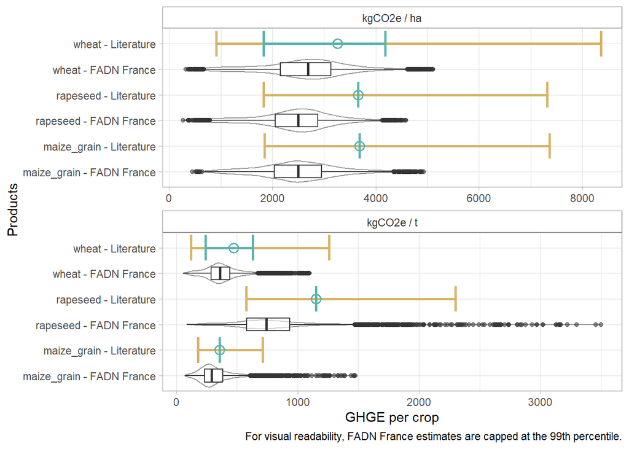

```r
# 3. Filter product and Winsorisation
tmp_plot_data <- dplyr::bind_rows(
  tmp_F2F_values0 |>
    dplyr::filter(estimate <= p99),
  tmp_lit_values0
) |>
  dplyr::filter(product_type == "Crops")


# 2. Create the plot
ggplot(tmp_plot_data) +
  # accepted range
  geom_errorbar(aes(x = product_source,
                    ymin = pmin(lit_midpoint, lit_min, na.rm = T) / 2,
                    ymax = pmax(lit_midpoint, lit_max, na.rm = T) * 2
                ), colour = "#d8b365",
                linewidth=1,width = 1,position = position_dodge(width = 0.75)) +
  # literature values
  geom_point(aes(x = product_source, y = lit_midpoint), colour = "#5ab4ac",
             shape = 1, size=3, stroke = 1, position = position_dodge(width = 0.75)) +
  # min and max
  geom_errorbar(aes(x = product_source, ymin = lit_min, ymax = lit_max), colour = "#5ab4ac",
                linewidth=1,width = 1,position = position_dodge(width = 0.75)) +
  # estimates
  geom_violin(aes(x = product_source, y = estimate, alpha = 0),
              colour = "#999999"
  ) +
  geom_boxplot(aes(x = product_source, y = estimate, alpha = 0),
               colour = "#333333", width = 0.5
  ) +
  # theme
  coord_flip() +
  facet_wrap(vars(unit_label), scales = "free",ncol = 1) +
  labs(y = "GHGE per crop",x= "Products",
       caption = "For visual readability, FADN France estimates are capped at the 99th percentile.") +
  scale_fill_viridis_d() +
  #  scale_fill_manual(values = tmp_FQS_names$colors,labels = tmp_FQS_names$labels,) +
  #  scale_colour_manual(values = tmp_FQS_names$colors,labels = tmp_FQS_names$labels) +
  theme_light() +
  theme(
    legend.position = c(0,-1),legend.direction = "horizontal",legend.title = element_blank(),
    strip.background = element_rect(fill = NA, colour = "#999999"),strip.text = element_text(color = "#333333"))
```

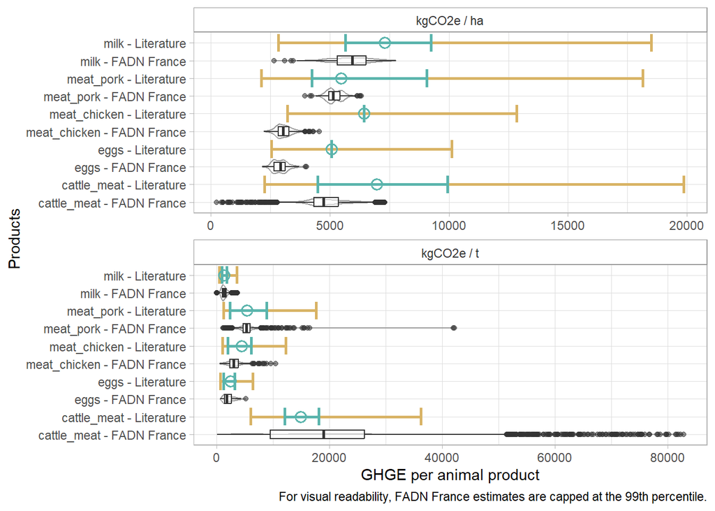

```r
# 3. Filter product and Winsorisation
tmp_plot_data <- dplyr::bind_rows(
  tmp_F2F_values0 |>
    dplyr::filter(estimate <= p99),
  tmp_lit_values0
) |>
  dplyr::filter(product_type != "Crops")


# 2. Create the plot
ggplot(tmp_plot_data) +
  # accepted range
  geom_errorbar(aes(x = product_source,
                    ymin = pmin(lit_midpoint, lit_min, na.rm = T) / 2,
                    ymax = pmax(lit_midpoint, lit_max, na.rm = T) * 2
                ), colour = "#d8b365",
                linewidth=1,width = 1,position = position_dodge(width = 0.75)) +
  # literature values
  geom_point(aes(x = product_source, y = lit_midpoint), colour = "#5ab4ac",
             shape = 1, size=3, stroke = 1, position = position_dodge(width = 0.75)) +
  # min and max
  geom_errorbar(aes(x = product_source, ymin = lit_min, ymax = lit_max), colour = "#5ab4ac",
                linewidth=1,width = 1,position = position_dodge(width = 0.75)) +
  # estimates
  geom_violin(aes(x = product_source, y = estimate, alpha = 0),
              colour = "#999999"
  ) +
  geom_boxplot(aes(x = product_source, y = estimate, alpha = 0),
               colour = "#333333", width = 0.5
  ) +
  # theme
  coord_flip() +
  facet_wrap(vars(unit_label), scales = "free",ncol = 1) +
  labs(y = "GHGE per animal product",x= "Products",
       caption = "For visual readability, FADN France estimates are capped at the 99th percentile.") +
  scale_fill_viridis_d() +
  #  scale_fill_manual(values = tmp_FQS_names$colors,labels = tmp_FQS_names$labels,) +
  #  scale_colour_manual(values = tmp_FQS_names$colors,labels = tmp_FQS_names$labels) +
  theme_light() +
  theme(
    legend.position = c(0,-1),legend.direction = "horizontal",legend.title = element_blank(),
    strip.background = element_rect(fill = NA, colour = "#999999"),strip.text = element_text(color = "#333333"))
```

```r
tmp_outliers = head(tmp_F2F_values0 |>
                      dplyr::filter(grepl("per_t", unit)) |>
                      dplyr::arrange(-estimate),
                    n = 15)

tmp_outliers
```

```
# A tibble: 15 × 12
   ID         YEAR  COUNTRY product indicator estimate unit  Category unit_label
   <chr>      <chr> <chr>   <chr>   <chr>        <dbl> <chr> <chr>    <chr>
 1 521000000… 2017  FRA     meat_p… GHGE_kgC… 2249022. kgCO… <NA>     kgCO2e / t
 2 105000000… 2018  FRA     meat_p… GHGE_kgC… 1453889. kgCO… <NA>     kgCO2e / t
 3 571000000… 2020  FRA     cattle… GHGE_kgC… 1411359. kgCO… <NA>     kgCO2e / t
 4 596000000… 2017  FRA     cattle… GHGE_kgC…  837076. kgCO… <NA>     kgCO2e / t
 5 576000000… 2021  FRA     cattle… GHGE_kgC…  686489. kgCO… <NA>     kgCO2e / t
 6 521000000… 2020  FRA     meat_p… GHGE_kgC…  664728. kgCO… <NA>     kgCO2e / t
 7 521000000… 2017  FRA     cattle… GHGE_kgC…  590595. kgCO… <NA>     kgCO2e / t
 8 105000000… 2020  FRA     cattle… GHGE_kgC…  567215. kgCO… <NA>     kgCO2e / t
 9 521000000… 2021  FRA     meat_p… GHGE_kgC…  525144. kgCO… <NA>     kgCO2e / t
10 594000000… 2020  FRA     cattle… GHGE_kgC…  503332. kgCO… <NA>     kgCO2e / t
11 571000000… 2021  FRA     cattle… GHGE_kgC…  442248. kgCO… <NA>     kgCO2e / t
12 105000000… 2019  FRA     cattle… GHGE_kgC…  436684. kgCO… <NA>     kgCO2e / t
13 521000000… 2021  FRA     cattle… GHGE_kgC…  419827. kgCO… <NA>     kgCO2e / t
14 104000000… 2020  FRA     meat_p… GHGE_kgC…  418939. kgCO… <NA>     kgCO2e / t
15 567000000… 2019  FRA     cattle… GHGE_kgC…  248998. kgCO… <NA>     kgCO2e / t
# ℹ 3 more variables: product_type <fct>, product_source <chr>, p99 <dbl>
```

```r
tmp_outliers_obj = m_keep_farms(
  my_object_GHGE,
  tmp_outliers
)

# compare feed
dplyr::left_join(
  my_object_GHGE@practices$herding$feed$feed_intake$total |>
    dplyr::summarise(
      DM_t_anim = mean(DM_t_anim, na.rm = TRUE),
      GE_MJ_anim = mean(GE_MJ_anim, na.rm =TRUE),
      .by = FADN_code_letter
    ),
  tmp_outliers_obj@practices$herding$feed$feed_intake$total |>
    dplyr::summarise(
      DM_t_anim_outliers = mean(DM_t_anim, na.rm = TRUE),
      GE_MJ_anim_outliers = mean(GE_MJ_anim, na.rm =TRUE),
      .by = FADN_code_letter
    )
)
```

```
# A tibble: 22 × 5
   FADN_code_letter DM_t_anim GE_MJ_anim DM_t_anim_outliers GE_MJ_anim_outliers
   <chr>                <dbl>      <dbl>              <dbl>               <dbl>
 1 LPIGFAT             0.951      17891.              1.19               22257.
 2 LPIGLET             0.0952      1797.              0.107               2003.
 3 LPIGOTH             0.959      18040.              1.19               22257.
 4 LSOWBRE             1.59       29981.              1.99               37017.
 5 LHENSLAY            0.0993      1876.             NA                     NA
 6 LBOV1               0.713      13300.              0.797              14808.
 7 LBOV1_2F            2.60       48434.              3.00               55690.
 8 LBOV2               6.33      117423.              9.69              179855.
 9 LCOWOTH             7.19      133410.              9.65              179021.
10 LHEIFBRE            4.74       88457.              3.86               71905.
# ℹ 12 more rows
```

```r
# compare GHGE components

dplyr::left_join(
  my_object_GHGE@footprints$GHGE$GHGE_meat |>
    dplyr::summarise(dplyr::across(
      .cols = dplyr::matches("kgCO2e"),
      .fns = ~sum(.x, na.rm = TRUE)
    ),
    .by = c(output, species)) |>
    tidyr::pivot_longer(
      cols = dplyr::matches("kgCO2e")
    ),

  tmp_outliers_obj@footprints$GHGE$GHGE_meat |>
    dplyr::summarise(dplyr::across(
      .cols = dplyr::matches("kgCO2e"),
      .fns = ~sum(.x, na.rm = TRUE)
    ),
    .by = c(output, species)) |>
    tidyr::pivot_longer(
      cols = dplyr::matches("kgCO2e"),
      values_to = "value_outlier"
    ),
  by = c('output', 'species', 'name')
) |>
  dplyr::filter(!is.na(value_outlier)) |>
  dplyr::mutate(
    diff_p100 = abs(value_outlier - value) / value
  ) |>
  dplyr::arrange(-diff_p100)
```

```
# A tibble: 392 × 6
   output       species name                       value value_outlier diff_p100
   <chr>        <chr>   <chr>                      <dbl>         <dbl>     <dbl>
 1 meat_veal    cattle  feed_farm_ghg_ferti_prod… 1.51e7          0        1
 2 meat_veal    cattle  feed_farm_ghg_ferti_prod… 2.10e6          0        1
 3 meat_veal    cattle  feed_farm_ghg_ferti_prod… 2.99e6          0        1
 4 meat_veal    cattle  feed_pseudofarm_ghg_fert… 2.75e6          9.91     1.000
 5 meat_veal    cattle  feed_pseudofarm_ghg_fert… 2.33e7        446.       1.000
 6 meat_veal    cattle  feed_pseudofarm_ghg_elec… 5.07e4          2.05     1.000
 7 meat_pork    swine   ghg_elec_kgCO2e_livcat    1.04e7        525.       1.000
 8 meat_chicken <NA>    ghg_heat_fuel_kgCO2e_liv… 1.64e7       1007.       1.000
 9 meat_veal    cattle  pseudofarm_ghge_herd_kgC… 7.72e6        540.       1.000
10 meat_veal    cattle  feed_pseudofarm_ghg_fert… 4.69e6        404.       1.000
# ℹ 382 more rows
```

```r
tmp_data = tmp_F2F_values0 |>
                      dplyr::filter(grepl("per_ha", unit),
                                    grepl("cattle_meat", product))

tmp_quantile = quantile(tmp_data$estimate)

tmp_outliers_obj = m_keep_farms(
  my_object_GHGE,
  tmp_data |>
  dplyr::filter(estimate < tmp_quantile['25%'])
)

tmp_OK_farms <- m_keep_farms(
  my_object_GHGE,
  tmp_data |>
  dplyr::filter(estimate > tmp_quantile['75%'])
)
```

## Source of GHGE

```r
# 0. Summary table
F2F_output_ghge_compo0 |>
  summarise(
    n        = n(),
    mean     = mean(value, na.rm = TRUE),
    sd       = sd(value, na.rm = TRUE),
    min      = min(value, na.rm = TRUE),
    q25      = quantile(value, 0.25, na.rm = TRUE),
    median   = median(value, na.rm = TRUE),
    q75      = quantile(value, 0.75, na.rm = TRUE),
    max      = max(value, na.rm = TRUE),
    n_NA     = sum(is.na(value)),
    .by = c(product, unit, indicator)
  )
```

```
# A tibble: 68 × 12
   product  unit  indicator     n   mean    sd   min    q25 median    q75    max
   <chr>    <chr> <chr>     <int>  <dbl> <dbl> <dbl>  <dbl>  <dbl>  <dbl>  <dbl>
 1 wheat    kgCO… GHGE_kgC…  5803 1434.   500. 154.  1174.  1477.  1710.   9977.
 2 wheat    kgCO… GHGE_kgC…  5803  209.   167.  54.4  158.   198.   238.   8170.
 3 wheat    kgCO… GHGE_kgC…  5803  816.   389.   0    623.   849.  1021.   7663.
 4 wheat    kgCO… GHGE_kgC…  5803  121.   129.   0     81.5  113.   145.   6150.
 5 wheat    kgCO… GHGE_kgC…  5803  400.   280.   0    265.   364.   479.  10441.
 6 wheat    kgCO… GHGE_kgC…  5803   63.5  114.   0     35.2   49.4   70.5  5158.
 7 maize_g… kgCO… GHGE_kgC…  3083 1396.   423. 278.  1145.  1401.  1638.   4797.
 8 maize_g… kgCO… GHGE_kgC…  3083  194.   161.  49.1  132.   162.   211.   4399.
 9 maize_g… kgCO… GHGE_kgC…  3083  689.   315.   0    523.   705.   852.   3554.
10 maize_g… kgCO… GHGE_kgC…  3083   97.8  105.   0     58.5   80.3  111.   2795.
# ℹ 58 more rows
# ℹ 1 more variable: n_NA <int>
```

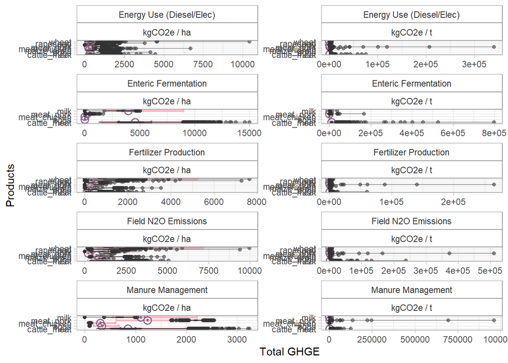

```r
# 1. Prepare data for plotting
tmp_F2F_values <- F2F_output_ghge_compo0 %>%
  # Extract the clean category name from the indicator string
  mutate(
    Category = str_extract(indicator, "(?<=__).*"),
    # Make unit names prettier for the plot labels
    unit_label = gsub("_per_"," / ", unit)
  )

tmp_lit_values <- lit_table |>
  dplyr::semi_join(
    tmp_F2F_values |>
      dplyr::select(product, unit, indicator) |>
      dplyr::distinct(),
    by = c('product', 'unit', 'indicator')
  ) |>
  # Extract the clean category name from the indicator string
  mutate(
    Category = str_extract(indicator, "(?<=__).*"),
    # Make unit names prettier for the plot labels
    unit_label = gsub("_per_"," / ", unit)
  )


# 2. Create the plot
ggplot() +
  # accepted range
  geom_errorbar(data = tmp_lit_values,
                aes(x = product,
                    ymin = pmin(lit_midpoint, lit_min, na.rm = T) / 2,
                    ymax = pmax(lit_midpoint, lit_max, na.rm = T) * 2
                ), colour = "lightpink",
                linewidth=1,width = 1,position = position_dodge(width = 0.75)) +
  # literature values
  geom_point(data = tmp_lit_values,
             aes(x = product, y = lit_midpoint), colour = "plum4",
             shape = 1, size=3, stroke = 1, position = position_dodge(width = 0.75)) +
  # min and max
  geom_errorbar(data = tmp_lit_values,
                aes(x = product, ymin = lit_min, ymax = lit_max), colour = "plum4",
                linewidth=1,width = 1,position = position_dodge(width = 0.75)) +
  # estimates
  geom_violin(data = tmp_F2F_values,
              aes(x = product, y = value, alpha = 0),
              colour = "#999999"
  ) +
  geom_boxplot(data = tmp_F2F_values,
               aes(x = product, y = value, alpha = 0),
               colour = "#333333", width = 0.25
  ) +
  # theme
  coord_flip() +
  facet_wrap(vars(Category, unit_label), scales = "free", ncol = 2) +
  labs(y = "Total GHGE",x= "Products") +
  scale_fill_viridis_d() +
  #  scale_fill_manual(values = tmp_FQS_names$colors,labels = tmp_FQS_names$labels,) +
  #  scale_colour_manual(values = tmp_FQS_names$colors,labels = tmp_FQS_names$labels) +
  theme_light() +
  theme(
    legend.position = c(0,-1),legend.direction = "horizontal",legend.title = element_blank(),
    strip.background = element_rect(fill = NA, colour = "#999999"),strip.text = element_text(color = "#333333"))
```

```r
# 1. Prepare data for plotting

tmp_plot_share <- dplyr::bind_rows(
  lit_table %>%
  # Filter only for the rows that contain the component breakdown (identified by __)
  filter(str_detect(indicator, "__")
         & unit == "kgCO2e_per_t") %>%
  # Extract the clean category name from the indicator string
  mutate(
    Category = str_extract(indicator, "(?<=__).*"),
    # Make unit names prettier for the plot labels
    unit_label = "kg CO2e / tonne"
  ) |>
    dplyr::filter(indicator %in% F2F_output_ghge_compo$indicator) |>
    dplyr::mutate(
      source = "Literature values",
      value = lit_midpoint
    ),
  F2F_output_ghge_compo %>%
  # Extract the clean category name from the indicator string
  mutate(
    Category = str_extract(indicator, "(?<=__).*"),
    # Make unit names prettier for the plot labels
    unit_label = gsub("_per_"," / ", unit),
          source = "F2F estimates",
      value = estimate
    )
) |>
  dplyr::filter(
    unit == "kgCO2e_per_t",
    grepl("wheat|milk|cattle_meat|meat_pork", product)
  )

cat(paste("Literature sources: ",paste0(unique(unlist(str_split(tmp_plot_share$lit_source, "; "))), collapse = "; ")))
```

```
Literature sources:  Bamber_2025_fig1; Bellassen_2021; Bamber_2025_sup_tab5; CAP2ER_2025_bovin_laitier; CAP2ER_2025_BV_E_JB_viande; CAP2ER_2025_BV_NE_boeufs; NA
```

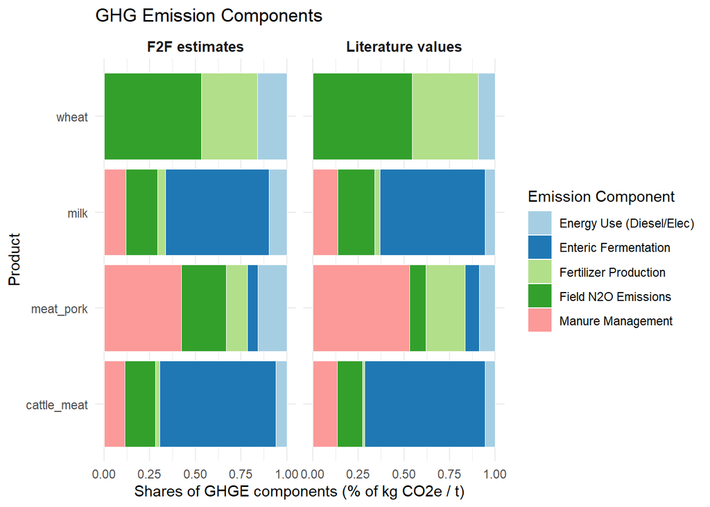

```r
# 2. Create the plot
ggplot(tmp_plot_share, aes(x = product, y = value, fill = Category)) +
  # Use stat = "identity" to plot the literal values in the table
  geom_bar(stat = "identity", position = "fill", color = "white", linewidth = 0.1) +
  # Facet by Product (rows) and Unit (columns)
  # scales = "free_y" is crucial because ha and t values are not comparable
  facet_grid(~ source) +
  # Styling
  scale_fill_brewer(palette = "Paired") + # Or use scale_fill_viridis_d()
  theme_minimal() +
  labs(
    title = "GHG Emission Components",
    #subtitle = paste("Literature sources: ",paste0(unique(unlist(str_split(tmp_plot_share$lit_source, "; "))), collapse = "; ")),
    x = "Product",
    y = "Shares of GHGE components (% of kg CO2e / t)",
    fill = "Emission Component"
  ) +
  theme(
    strip.text = element_text(face = "bold", size = 10),
    legend.position = "right",
    #axis.text.x = element_blank(), # Remove x axis text because it's redundant with facets
    axis.ticks.x = element_blank()
  ) +
  guides(fill = guide_legend(ncol = 1, title.position = "top")) +
  coord_flip()
```